# Bank Marketing Project

Keavatey Srun,Dilanka Wijeratne,Sai Vignesvar

9/23/2020

# 1. Introduction

The finance industry is one of the sectors that is being influenced most by the recent developments in the field of data analysis. Data Analysis can be a useful method for delivering greater profits, whether predicting asset prices, or in our case predicting whether a consumer will contribute to a term deposit.

This project aims to apply categorical analysis to predict the success of bank telemarketing.

To do this, we are going to use the *direct marketing campaign data* from UCI Machine Learning Repository called the Bank Marketing Data Set.

The marketing campaigns were based on direct phone calls. Often, *more than one contact* to the same client was required, in order to access if the product (bank term deposit) would be subscribed or not.

The aim of this project to apply categorical data analysis to predict the success of bank telemarketing.

To achieve that, first we needed to examine the different relationships between factor variables that might or might not play a crucial role in predicting the success or failure of the marketing effort. After analyzing the data, different models of logistic regression were fitted and compared to determine the best model to **predict** if a client may subscribe to a fixed term deposit. Each logistic regression model was formulated to predict the probability of the success of the marketing campaign given a combination of several factors.

Logistic regression model was used, as the response variable *y* is a binary response variable with levels *yes and no*.

For efficiency, the subset data of 5000 rows was used in the analysis instead of the whole original data.

We initially tried manual model fitting with all the variables. After which we performed feature selection to reduce the number of independent variables using Learning Vector Quantization (LVQ) model. Then model selection was performed with the 15 most important features using genetic Search and forward selection methods. The models obtained in the previous steps were compared and the best among them was chosen.

# 2. Data source

The data is sourced from https://raw.githubusercontent.com/vaksakalli/datasets/master/bank_marketing_full.csv. This dataset consists of 41,188 entries of the direct marketing campaigns of a Portuguese banking institution.

## Data Summary:

There are 20 explanatory observations containing 4 types of client data:  
1. **Bank Client Data**: age, job, marital status, education, default, housing and loan  
2. **Telemarketing data**: contact, month, day of the week, and duration  
3. **Socioeconomic data**: employment variation rate, consumer price index, consumer confidence index, 3 month Euribor rate, and number of employees  
4. **Other data**: campaign, past days, previous, and past outcome

## Data Description:

#### Bank Client Data:

1. **age** : person’s age in numerical value
2. **job** : type of job (categorical: ‘admin.’,‘blue-collar’,‘entrepreneur’,‘housemaid’,‘management’,‘retired’,‘self-employed’,‘services’,‘student’,‘technician’,‘unemployed’,‘unknown’)
3. **marital** : marital status (categorical: ‘divorced’,‘married’,‘single’,‘unknown’; note: ‘divorced’ means divorced or widowed)
4. **education** :(categorical)‘basic.4y’,‘basic.6y’,‘basic.9y’,‘high.school’,‘illiterate’,‘professional.course’,‘university.degree’,‘unknown’)
5. **default**: has credit in default? (categorical: ‘no’,‘yes’,‘unknown’)
6. **housing**: has housing loan? (categorical: ‘no’,‘yes’,‘unknown’)
7. **loan**: has personal loan? (categorical: ‘no’,‘yes’,‘unknown’)

#### Telemarketing Dat:

8. **contact**: contact communication type (categorical: ‘cellular’,‘telephone’)
9. **month**: last contact month of year (categorical: ‘jan’, ‘feb’, ‘mar’, …, ‘nov’, ‘dec’)
10. **day_of_week**: last contact day of the week (categorical: ‘mon’,‘tue’,‘wed’,‘thu’,‘fri’)
11. **duration**: last contact duration, in seconds (numeric). Important note: this attribute highly affects the output target (e.g., if duration=0 then y=‘no’). Yet, the duration is not known before a call is performed. Also, after the end of the call y is obviously known. Thus, this input should only be included for benchmark purposes and should be discarded if the intention is to have a realistic predictive model.

#### Other Data:

12. **campaign**: number of contacts performed during this campaign and for this client (numeric, includes last contact)
13. **pdays**: number of days that passed by after the client was last contacted from a previous campaign (numeric; 999 means client was not previously contacted)
14. **previous**: number of contacts performed before this campaign and for this client (numeric)
15. **poutcome**: outcome of the previous marketing campaign (categorical: ‘failure’,‘nonexistent’,‘success’)

#### Socioeconomic Data:

16. **emp.var.rate**: employment variation rate - quarterly indicator (numeric)
17. **cons.price.idx**: consumer price index - monthly indicator (numeric)
18. **cons.conf.idx**: consumer confidence index - monthly indicator (numeric)
19. **euribor3m**: euribor 3 month rate - daily indicator (numeric)
20. **nr.employed**: number of employees - quarterly indicator (numeric)

#### Output variable (desired target):

21. **y** - has the client subscribed a term deposit? (binary: ‘yes’,‘no’)

# 3. Data Pre-processing

## Loading pakages

```r
library(dplyr)
library(ggplot2)
library(tidyverse)
library(summarytools)
library(ggmosaic)
library(splitstackshape)
library(glmulti)
library(car)
library(spFSR)

SummaryStats <- function(x){
  descr(x, stats=c("min", "Q1", "mean","med", "Q3", "max", "IQR","sd"), transpose=TRUE)
}
```

## Loading dataset and checking its dimension

```r
data = read.csv("https://raw.githubusercontent.com/vaksakalli/datasets/master/bank_marketing_full.csv", stringsAsFactors = TRUE)
#Check data dimensions
dim(data)
```

```
## [1] 41188    21
```

We see that data has been loaded with accurate dimensions from the csv file.

## Taking random samples to check the data

```r
#Taking random sample of the data for checking
data[sample(1:nrow(data),10),]
```

```
##       age           job  marital           education default housing    loan
## 19801  38        admin.  married   university.degree      no      no      no
## 25582  46   blue-collar   single            basic.4y unknown      no      no
## 14337  43        admin. divorced         high.school      no     yes      no
## 8032   45        admin. divorced   university.degree unknown      no      no
## 14162  32        admin.   single   university.degree      no unknown unknown
## 24310  45    management  married   university.degree      no     yes      no
## 19193  44 self-employed  married professional.course      no     yes      no
## 30507  33      services  married         high.school      no      no     yes
## 31673  26      services   single   university.degree      no     yes      no
## 23094  45       unknown  married         high.school unknown     yes      no
##         contact month day_of_week duration campaign pdays previous    poutcome
## 19801  cellular   aug         fri      111        1   999        0 nonexistent
## 25582  cellular   nov         wed      584        1   999        1     failure
## 14337 telephone   jul         mon      109        6   999        0 nonexistent
```

[output cut: 18 more lines]

## Checking structure of the data

```r
str(data)
```

```
## 'data.frame':    41188 obs. of  21 variables:
##  $ age           : int  56 57 37 40 56 45 59 41 24 25 ...
##  $ job           : Factor w/ 12 levels "admin.","blue-collar",..: 4 8 8 1 8 8 1 2 10 8 ...
##  $ marital       : Factor w/ 4 levels "divorced","married",..: 2 2 2 2 2 2 2 2 3 3 ...
##  $ education     : Factor w/ 8 levels "basic.4y","basic.6y",..: 1 4 4 2 4 3 6 8 6 4 ...
##  $ default       : Factor w/ 3 levels "no","unknown",..: 1 2 1 1 1 2 1 2 1 1 ...
##  $ housing       : Factor w/ 3 levels "no","unknown",..: 1 1 3 1 1 1 1 1 3 3 ...
##  $ loan          : Factor w/ 3 levels "no","unknown",..: 1 1 1 1 3 1 1 1 1 1 ...
##  $ contact       : Factor w/ 2 levels "cellular","telephone": 2 2 2 2 2 2 2 2 2 2 ...
##  $ month         : Factor w/ 10 levels "apr","aug","dec",..: 7 7 7 7 7 7 7 7 7 7 ...
##  $ day_of_week   : Factor w/ 5 levels "fri","mon","thu",..: 2 2 2 2 2 2 2 2 2 2 ...
##  $ duration      : int  261 149 226 151 307 198 139 217 380 50 ...
##  $ campaign      : int  1 1 1 1 1 1 1 1 1 1 ...
##  $ pdays         : int  999 999 999 999 999 999 999 999 999 999 ...
##  $ previous      : int  0 0 0 0 0 0 0 0 0 0 ...
##  $ poutcome      : Factor w/ 3 levels "failure","nonexistent",..: 2 2 2 2 2 2 2 2 2 2 ...
##  $ emp.var.rate  : num  1.1 1.1 1.1 1.1 1.1 1.1 1.1 1.1 1.1 1.1 ...
##  $ cons.price.idx: num  94 94 94 94 94 ...
##  $ cons.conf.idx : num  -36.4 -36.4 -36.4 -36.4 -36.4 -36.4 -36.4 -36.4 -36.4 -36.4 ...
##  $ euribor3m     : num  4.86 4.86 4.86 4.86 4.86 ...
##  $ nr.employed   : num  5191 5191 5191 5191 5191 ...
##  $ y             : Factor w/ 2 levels "no","yes": 1 1 1 1 1 1 1 1 1 1 ...
```

## Checking for missing values

We see that there are no missing values in this data.

```r
#Total missing values in each column
sapply(data, function(x) sum(is.na(x)))
```

```
##            age            job        marital      education        default
##              0              0              0              0              0
##        housing           loan        contact          month    day_of_week
##              0              0              0              0              0
##       duration       campaign          pdays       previous       poutcome
##              0              0              0              0              0
##   emp.var.rate cons.price.idx  cons.conf.idx      euribor3m    nr.employed
##              0              0              0              0              0
##              y
##              0
```

## Dropping columns

> There is an important note that comes with the dataset on “duration” feature saying this attribute highly affects the output target (e.g., if duration=0 then y=‘no’). Yet, the duration is not known before a call is performed. Also, after the end of the call y is obviously known. Since we want to have a realistic predictive model, this feature will be dropped to avoid such an sensitive impact on the outcome.

```r
data <- data %>% select(-duration)
dim(data)
```

```
## [1] 41188    20
```

## Unusual values

In pdays feature, there are some values labeled as 999. It means client was not previously contacted, and there are 39,673 rows that contain these values.This means over 96% of the clients in this data was not previously contacted. Thus, for the sake of simplicity, we transform this feature into a categorical feature with two levels. 0 = not previously contacted and 1 = have contacted.

```r
#count data with 999 values in pdays
data %>% filter(pdays==999) %>% nrow()
```

```
## [1] 39673
```

```r
#changing pdays to Yes/No factor level
data <- data %>% mutate (pdays =  if_else(data$pdays==999,0,1))
data$pdays <- as.factor(data$pdays)
levels(data$pdays)
```

```
## [1] "0" "1"
```

## Reorder the level of some categorical features

For quicker and easier read, we reorder and relabel some of the categorical features below.

```r
data$marital <- factor(data$marital,levels=c("single","married", "divorced", "unknown"),labels=c("single","married", "divorced", "unknown"))
data$education <- factor(data$education,levels=c("illiterate", "basic.4y", "basic.6y", "basic.9y", "high.school", "professional.course","university.degree", "unknown"),labels=c("illiterate", "basic 4y", "basic 6y", "basic 9y", "high school", "professional course","university degree", "unknown"))
data$month <- factor(data$month,levels=c("mar", "apr", "may", "jun", "jul", "aug", "sep", "oct", "nov", "dec"),labels=c("mar", "apr", "may", "jun", "jul", "aug", "sep", "oct", "nov", "dec"))
data$day_of_week <- factor(data$day_of_week,levels=c("mon", "tue", "wed", "thu","fri"),labels=c("mon", "tue", "wed", "thu","fri"))
data$pdays <- factor(data$pdays,levels=c("0","1"),labels=c('Not previously contacted','Have contacted'))

str(data)
```

```
## 'data.frame':    41188 obs. of  20 variables:
##  $ age           : int  56 57 37 40 56 45 59 41 24 25 ...
##  $ job           : Factor w/ 12 levels "admin.","blue-collar",..: 4 8 8 1 8 8 1 2 10 8 ...
##  $ marital       : Factor w/ 4 levels "single","married",..: 2 2 2 2 2 2 2 2 1 1 ...
##  $ education     : Factor w/ 8 levels "illiterate","basic 4y",..: 2 5 5 3 5 4 6 8 6 5 ...
##  $ default       : Factor w/ 3 levels "no","unknown",..: 1 2 1 1 1 2 1 2 1 1 ...
##  $ housing       : Factor w/ 3 levels "no","unknown",..: 1 1 3 1 1 1 1 1 3 3 ...
##  $ loan          : Factor w/ 3 levels "no","unknown",..: 1 1 1 1 3 1 1 1 1 1 ...
##  $ contact       : Factor w/ 2 levels "cellular","telephone": 2 2 2 2 2 2 2 2 2 2 ...
##  $ month         : Factor w/ 10 levels "mar","apr","may",..: 3 3 3 3 3 3 3 3 3 3 ...
##  $ day_of_week   : Factor w/ 5 levels "mon","tue","wed",..: 1 1 1 1 1 1 1 1 1 1 ...
##  $ campaign      : int  1 1 1 1 1 1 1 1 1 1 ...
##  $ pdays         : Factor w/ 2 levels "Not previously contacted",..: 1 1 1 1 1 1 1 1 1 1 ...
##  $ previous      : int  0 0 0 0 0 0 0 0 0 0 ...
##  $ poutcome      : Factor w/ 3 levels "failure","nonexistent",..: 2 2 2 2 2 2 2 2 2 2 ...
##  $ emp.var.rate  : num  1.1 1.1 1.1 1.1 1.1 1.1 1.1 1.1 1.1 1.1 ...
##  $ cons.price.idx: num  94 94 94 94 94 ...
##  $ cons.conf.idx : num  -36.4 -36.4 -36.4 -36.4 -36.4 -36.4 -36.4 -36.4 -36.4 -36.4 ...
##  $ euribor3m     : num  4.86 4.86 4.86 4.86 4.86 ...
##  $ nr.employed   : num  5191 5191 5191 5191 5191 ...
##  $ y             : Factor w/ 2 levels "no","yes": 1 1 1 1 1 1 1 1 1 1 ...
```

```r
write.csv(data, 'data_clean.csv')
```

# 4. Descriptive Statistics

## Numerical Features

```r
#Selecting Numerical Columns
numeric <- data %>% select_if(is.numeric)
SummaryStats(numeric)
```

```
## Descriptive Statistics
## x
## N: 41188
##
##                            Min        Q1      Mean    Median        Q3       Max      IQR   Std.Dev
## -------------------- --------- --------- --------- --------- --------- --------- -------- ---------
##                  age     17.00     32.00     40.02     38.00     47.00     98.00    15.00     10.42
##             campaign      1.00      1.00      2.57      2.00      3.00     56.00     2.00      2.77
##        cons.conf.idx    -50.80    -42.70    -40.50    -41.80    -36.40    -26.90     6.30      4.63
##       cons.price.idx     92.20     93.08     93.58     93.75     93.99     94.77     0.92      0.58
##         emp.var.rate     -3.40     -1.80      0.08      1.10      1.40      1.40     3.20      1.57
##            euribor3m      0.63      1.34      3.62      4.86      4.96      5.04     3.62      1.73
##          nr.employed   4963.60   5099.10   5167.04   5191.00   5228.10   5228.10   129.00     72.25
##             previous      0.00      0.00      0.17      0.00      0.00      7.00     0.00      0.49
```

```r
#Gather the data into two columns
df_num <- numeric %>% gather(features, value, 1:ncol(numeric))
```

## Box plots of each numerical features

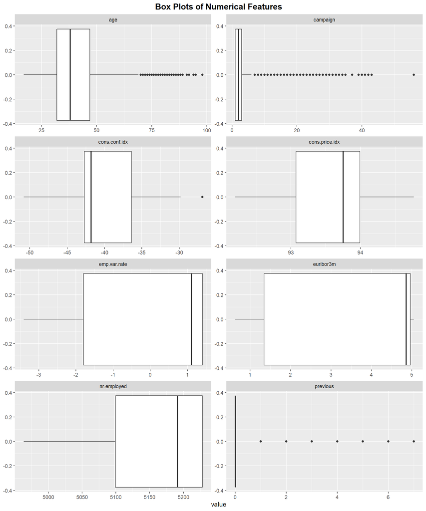

```r
ggplot(df_num, aes(x = value)) + geom_boxplot() + facet_wrap(~features, scales = "free", ncol = 2)+ labs(title="Box Plots of Numerical Features") + theme(plot.title=element_text(hjust=0.5,face="bold", size=14))
```

Based on box plots, we see that there are some outliers in age, campaign and previous features.However, those are not extreme values. Since we do not have enough evidence to remove these, the values will be kept as it is.

## Categorical Features

```r
#Selection Categorical Columns
categorical <- data %>% select_if(is.factor)

for (i in 1:ncol(categorical)){
  categorical_cols <- names(categorical)
  cat(categorical_cols[i],":")
  x <- data.frame(table(categorical[,i]))
  names(x) <- NULL
  print(x)
  cat("\n")
}
```

```
## job :
## 1         admin. 10422
## 2    blue-collar  9254
## 3   entrepreneur  1456
## 4      housemaid  1060
## 5     management  2924
## 6        retired  1720
## 7  self-employed  1421
## 8       services  3969
## 9        student   875
## 10    technician  6743
## 11    unemployed  1014
## 12       unknown   330
##
## marital :
```

[output cut: 65 more lines]

# 5. Data Exploration and Visualization

## Univariate plots

```r
target <- data %>%
  group_by(y) %>%
  summarise(n = length(y)) %>%
  arrange(desc(y)) %>%
  mutate(prop=round(n/nrow(data)*100,2))%>%
  mutate(ypos = cumsum(prop)- 0.5*prop )
target
```

```
## # A tibble: 2 x 4
##   y         n  prop  ypos
##   <fct> <int> <dbl> <dbl>
## 1 yes    4640  11.3  5.64
## 2 no    36548  88.7 55.6
```

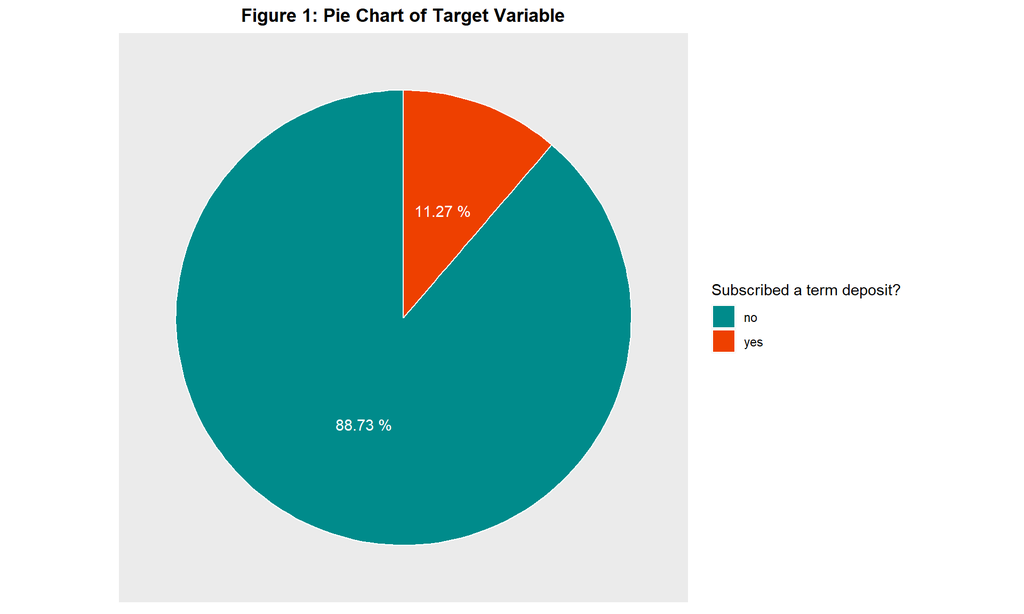

```r
p1 <- ggplot(target, aes(x="", y=prop, fill=y)) +geom_bar(width = 1, stat="identity", color="white") + coord_polar("y", start=0) + geom_text(aes(y=ypos, label=paste(prop, "%")), color="white")
p1 + labs(title="Figure 1: Pie Chart of Target Variable", fill="Subscribed a term deposit?") +
  theme(axis.ticks=element_blank(),
        axis.title=element_blank(),
        axis.text.y=element_blank(),
        axis.text.x=element_blank(),
        panel.grid.major = element_blank(),
        panel.grid.minor = element_blank(),
        panel.border = element_blank(),
        plot.title=element_text(hjust=0.5,face="bold", size=13)) +scale_fill_manual(values=c("cyan4", "orangered2"))
```

**From Figure 1, we can see that the dependent variable ‘Y’ has 88.73% “no” and 11.27% “yes”. This suggests the data is *highly imbalanced* since one class is about 8 times higher than another.**

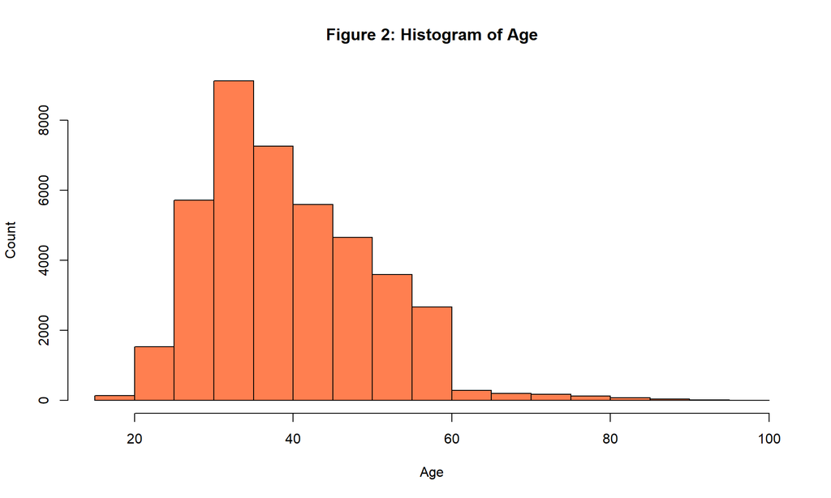

```r
hist(data$age, ylab="Count", xlab="Age", main="Figure 2: Histogram of Age", col = "coral")
```

**Figure 2 shows that the distribution of age is right skewed which center of distribution around 30-40 years.**

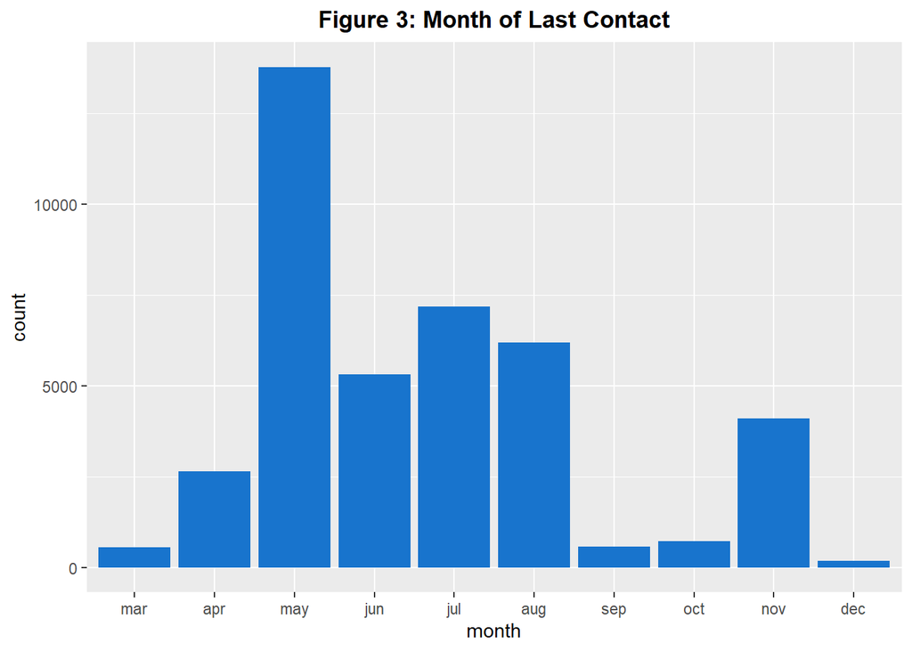

```r
days <- data %>% group_by(month) %>%
  summarise(count = n())

p3 <- ggplot(days, aes(x=month, y=count))
p3+geom_bar(stat="identity", fill = "dodgerblue3") +labs(title="Figure 3: Month of Last Contact")+theme(plot.title=element_text(hjust=0.5,face="bold", size=13))
```

**From Figure 3, we can see that large call volumes happened in May, while normal volumes were through June to August and the least one was during December. It should also be noted that Jan and Feb have either not been recorded or there were no calls during this time.**

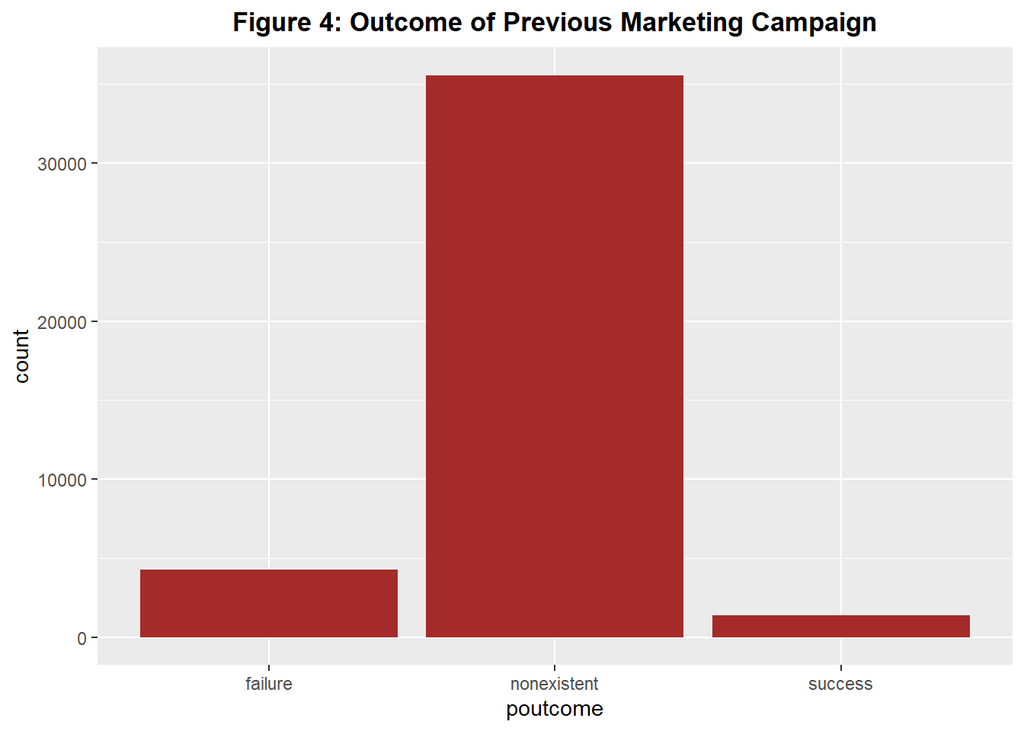

```r
poutcome <- data %>% group_by(poutcome) %>%
  summarise(count = n())

p4 <- ggplot(poutcome, aes(x=poutcome, y=count))
p4+geom_bar(stat="identity", fill = "brown") +labs(title="Figure 4: Outcome of Previous Marketing Campaign")+theme(plot.title=element_text(hjust=0.5,face="bold", size=13))
```

**From Figure 4, we can see that previous marketing outcome are largely nonexistent. Only a very few instances it has made an impact.**

## Bivariate plots

```r
marital<- table(data$marital,data$y, dnn=c("marital", "outcome"))
marital %>% knitr::kable( caption =  'Table 1: Marital Status on Outcome')
```

Table 1: Marital Status on Outcome

|  | no | yes |
| --- | --- | --- |
| single | 9948 | 1620 |
| married | 22396 | 2532 |
| divorced | 4136 | 476 |
| unknown | 68 | 12 |

```r
marital_prop <- round(prop.table(marital,1),2)
marital_prop %>% knitr::kable( caption =  'Table 2: Marital Status Proportion on Outcome')
```

Table 2: Marital Status Proportion on Outcome

|  | no | yes |
| --- | --- | --- |
| single | 0.86 | 0.14 |
| married | 0.90 | 0.10 |
| divorced | 0.90 | 0.10 |
| unknown | 0.85 | 0.15 |

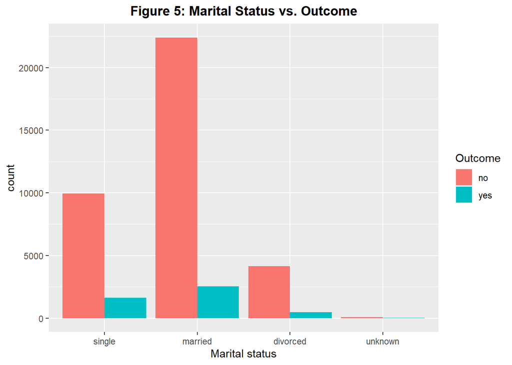

```r
p5 <- ggplot(data, aes(x=marital, fill=y))
p5+geom_bar(position="dodge") +
  labs(title="Figure 5: Marital Status vs. Outcome",
       x="Marital status",
       fill="Outcome")+
  theme(plot.title=element_text(hjust=0.5,face="bold", size=13))
```

**Figure 5 shows us the outcome of marketing campaign for each marital status. We can see that married people say yes to term deposit slightly more than single and divorced people. However, if we compare the proportion of “yes” and “no”, people who are single subscribe to term deposit more than others.**

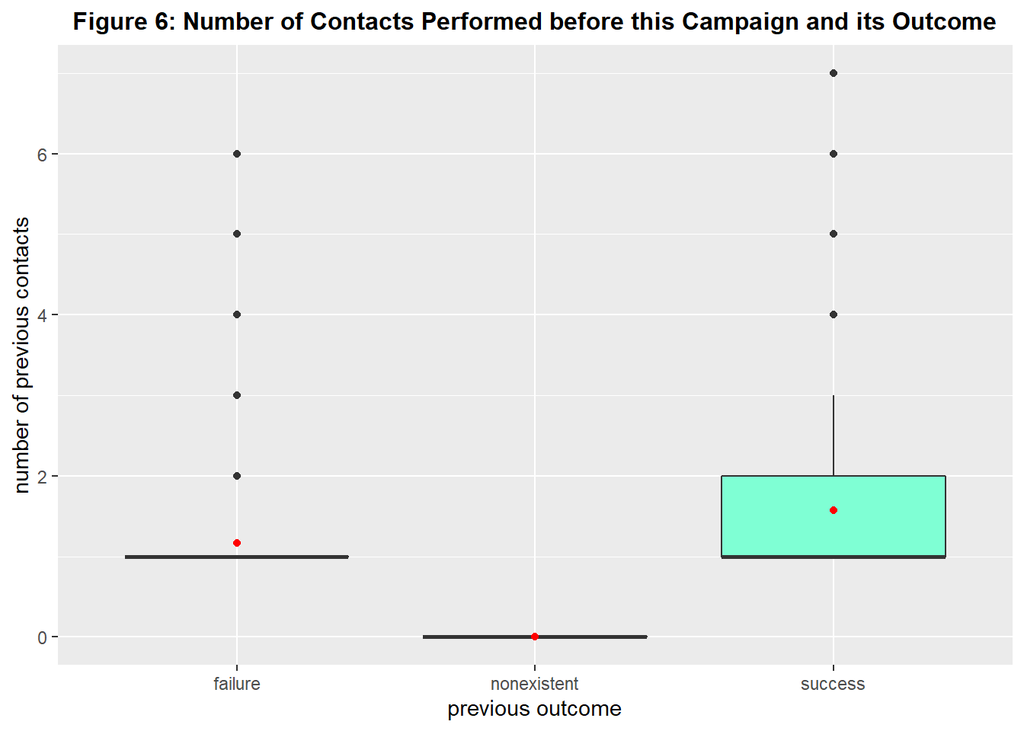

```r
p6 <- ggplot(data, aes(x=poutcome, y=previous))
p6+geom_boxplot(fill="aquamarine1")+stat_summary(fun.y="mean", geom="point", colour="red")+
  labs(title="Figure 6: Number of Contacts Performed before this Campaign and its Outcome",
       x="previous outcome",
       y="number of previous contacts")+
  theme(plot.title=element_text(hjust=0.5,face="bold", size=12))
```

**In Figure 6, we can see the number of contacts performed before this campaign and its impact on outcome. The graph suggests that sometimes more number of contacts performed can be successful for the campaign**

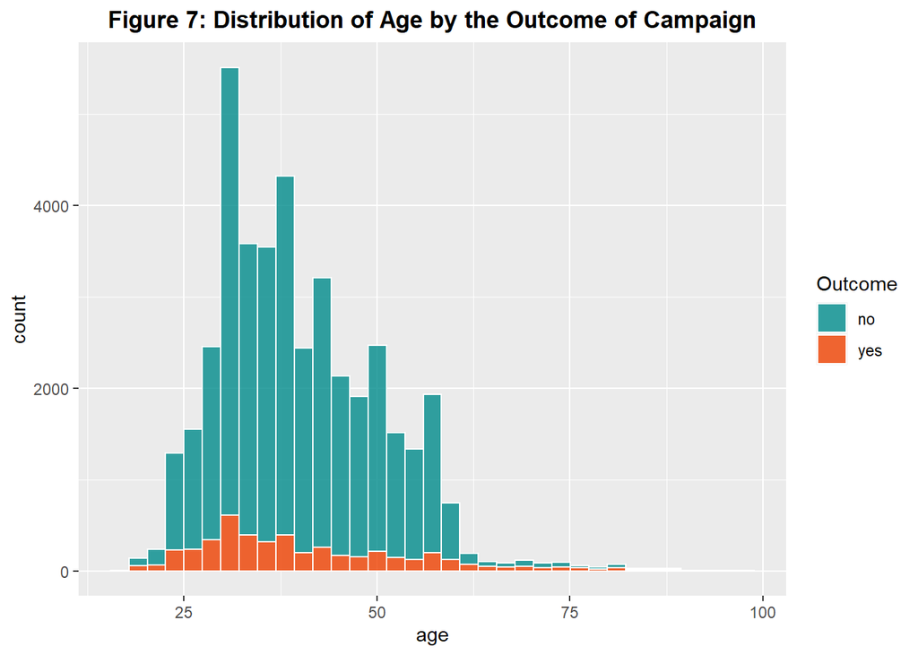

```r
p7 <- ggplot(data, aes(age, fill=y))
p7+geom_histogram(bins=35,alpha=0.8,color="white") +labs(title="Figure 7: Distribution of Age by the Outcome of Campaign", fill="Outcome")+theme(plot.title=element_text(hjust=0.5,face="bold", size=13))+scale_fill_manual(values=c("cyan4", "orangered2"))
```

**In Figure 7, we can see the impact of age on the outcome of the campaign. The distribution of age between the two outcomes are almost the same. That means age does not play significant role in the outcome of marketing campaign**

```r
job<- table(data$job,data$y, dnn=c("jobs", "outcome"))
job_prop <- round(prop.table(job,1),2)
job_prop %>% knitr::kable( caption =  'Table 3: Type of Jobs Proportion on Outcome')
```

Table 3: Type of Jobs Proportion on Outcome

|  | no | yes |
| --- | --- | --- |
| admin. | 0.87 | 0.13 |
| blue-collar | 0.93 | 0.07 |
| entrepreneur | 0.91 | 0.09 |
| housemaid | 0.90 | 0.10 |
| management | 0.89 | 0.11 |
| retired | 0.75 | 0.25 |
| self-employed | 0.90 | 0.10 |
| services | 0.92 | 0.08 |
| student | 0.69 | 0.31 |
| technician | 0.89 | 0.11 |
| unemployed | 0.86 | 0.14 |
| unknown | 0.89 | 0.11 |

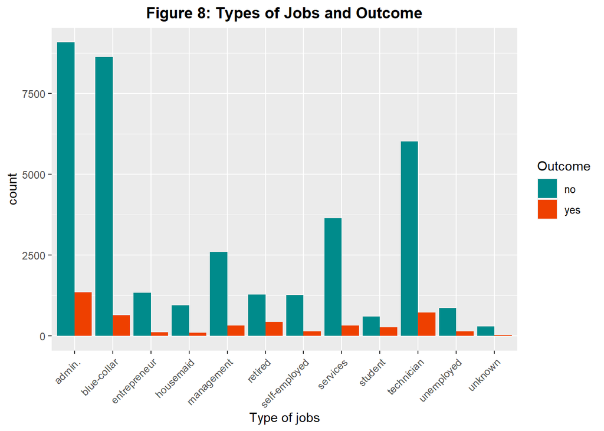

```r
p8 <- ggplot(data, aes(x=job, fill=y))
p8+geom_bar(position="dodge") +labs(title="Figure 8: Types of Jobs and Outcome",
                                    x="Type of jobs", fill="Outcome")+theme(axis.text.x=element_text(angle=45,hjust=1),plot.title=element_text(hjust=0.5,face="bold", size=13)) + scale_fill_manual(values=c("cyan4", "orangered2"))
```

**In Figure 8, We can see the impact of jobs on the outcome of the campaign. Students and retired people have the highest proportion of success outcome followed by unemployed and admin.**

```r
education<- table(data$education,data$y, dnn=c("education", "outcome"))
edu_prop <- round(prop.table(education,1),2)
edu_prop %>% knitr::kable( caption =  'Table 4: Education Status Proportion on Outcome')
```

Table 4: Education Status Proportion on Outcome

|  | no | yes |
| --- | --- | --- |
| illiterate | 0.78 | 0.22 |
| basic 4y | 0.90 | 0.10 |
| basic 6y | 0.92 | 0.08 |
| basic 9y | 0.92 | 0.08 |
| high school | 0.89 | 0.11 |
| professional course | 0.89 | 0.11 |
| university degree | 0.86 | 0.14 |
| unknown | 0.85 | 0.15 |

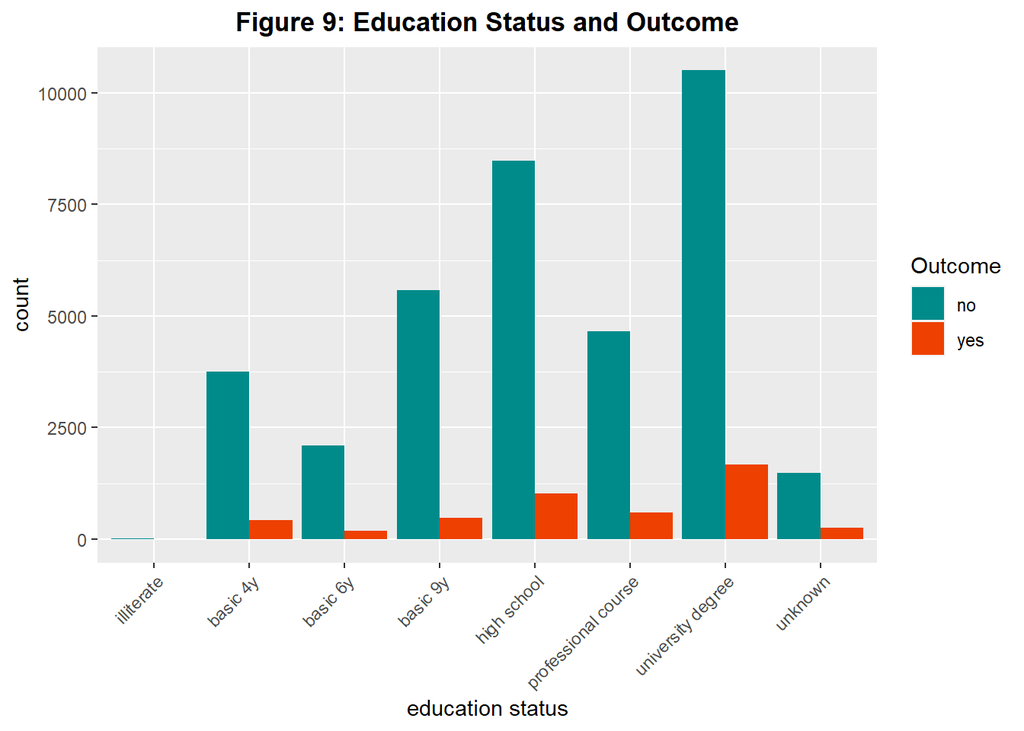

```r
p9 <- ggplot(data, aes(x=education, fill=y))
p9+geom_bar(position="dodge") +labs(title="Figure 9: Education Status and Outcome",
                                    x="education status", fill="Outcome")+theme(axis.text.x=element_text(angle=45,hjust=1),plot.title=element_text(hjust=0.5,face="bold", size=13)) + scale_fill_manual(values=c("cyan4", "orangered2"))
```

**From Table 4, we can see people who are illiterate have the highest proportion of success outcome followed by those with unknown education status and those with university degree. Figure 9 indicates that clients with university degree were contacted more than other people.**

```r
housing<- table(data$housing,data$y, dnn=c("Housing Loan", "Outcome"))
housing_prop <- round(prop.table(housing,1),2)
housing_prop %>% knitr::kable( caption =  'Table 5: Housing Loan Status Proportion on Outcome')
```

Table 5: Housing Loan Status Proportion on Outcome

|  | no | yes |
| --- | --- | --- |
| no | 0.89 | 0.11 |
| unknown | 0.89 | 0.11 |
| yes | 0.88 | 0.12 |

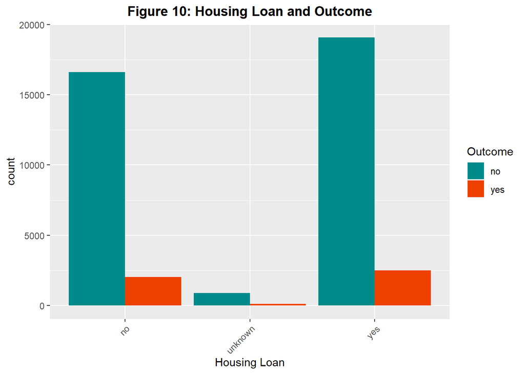

```r
p10 <- ggplot(data, aes(x=housing, fill=y))
p10+geom_bar(position="dodge") +labs(title="Figure 10: Housing Loan and Outcome",
                                    x="Housing Loan", fill="Outcome")+theme(axis.text.x=element_text(angle=45,hjust=1),plot.title=element_text(hjust=0.5,face="bold", size=13)) + scale_fill_manual(values=c("cyan4", "orangered2"))
```

**From Table 5, it seems housing loan status does not influence the outcome of the marketing campaign since the proportion of success across the housing loan status is the same.**

```r
loan<- table(data$loan,data$y, dnn=c("loan", "outcome"))
loan_prop <- round(prop.table(loan,1),2)
loan_prop %>% knitr::kable( caption =  'Table 6: Personal Loan Status Proportion on Outcome')
```

Table 6: Personal Loan Status Proportion on Outcome

|  | no | yes |
| --- | --- | --- |
| no | 0.89 | 0.11 |
| unknown | 0.89 | 0.11 |
| yes | 0.89 | 0.11 |

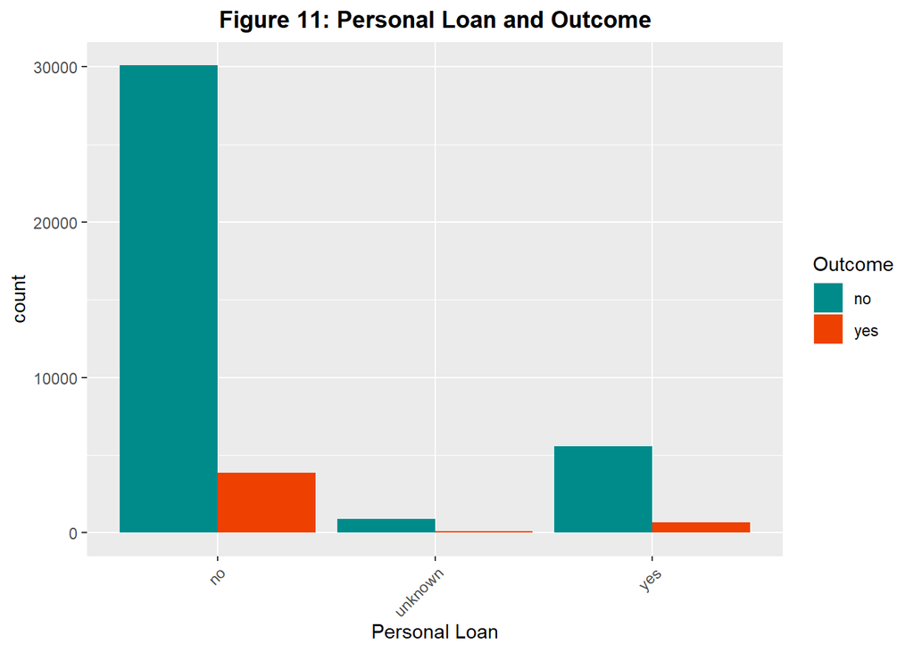

```r
p11 <- ggplot(data, aes(x=loan, fill=y))
p11+geom_bar(position="dodge") +labs(title="Figure 11: Personal Loan and Outcome",
                                    x="Personal Loan", fill="Outcome")+theme(axis.text.x=element_text(angle=45,hjust=1),plot.title=element_text(hjust=0.5,face="bold", size=13)) + scale_fill_manual(values=c("cyan4", "orangered2"))
```

**From the Table 6 and Figure 11, we can see the same thing is for personal loan as housing loan status. The personal loan status does not seem to influence the outcome of the campaign although it is worth noting that most clients recorded in the data have no personal loan.**

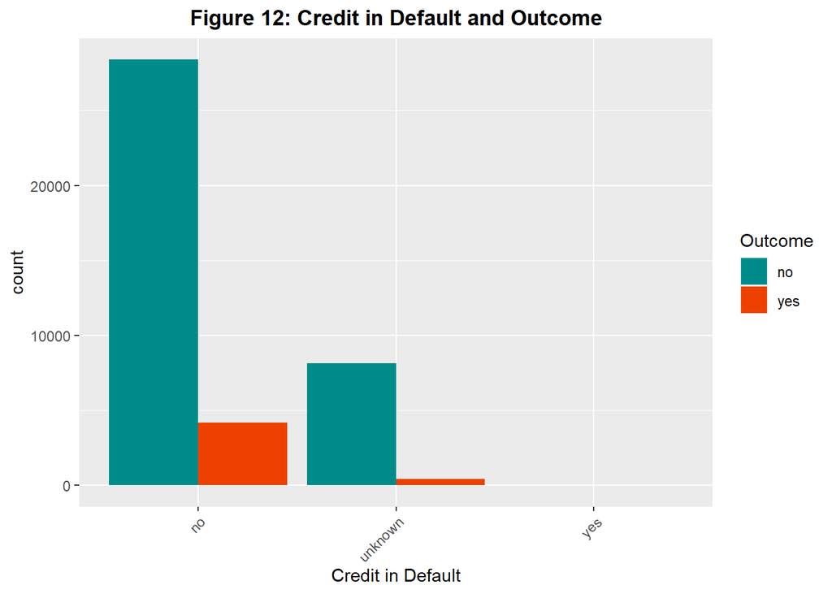

```r
p12 <- ggplot(data, aes(x=default, fill=y))
p12+geom_bar(position="dodge") +labs(title="Figure 12: Credit in Default and Outcome",
                                    x="Credit in Default", fill="Outcome")+theme(axis.text.x=element_text(angle=45,hjust=1),plot.title=element_text(hjust=0.5,face="bold", size=13)) + scale_fill_manual(values=c("cyan4", "orangered2"))
```

**From Figure 12, we see that there are no clients reported with credit in default in the data.**

```r
contact<- table(data$contact,data$y, dnn=c("contact", "outcome"))
contact_prop <- round(prop.table(contact,1),2)
contact_prop %>% knitr::kable( caption =  'Table 6: Mode of Communication Proportion on Outcome')
```

Table 6: Mode of Communication Proportion on Outcome

|  | no | yes |
| --- | --- | --- |
| cellular | 0.85 | 0.15 |
| telephone | 0.95 | 0.05 |

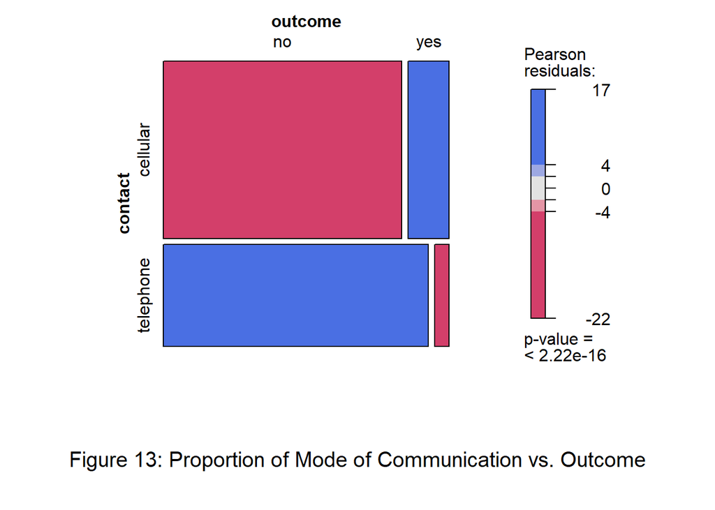

```r
vcd::mosaic(contact, pop=FALSE, legend=TRUE, shade=TRUE, sub="Figure 13: Proportion of Mode of Communication vs. Outcome")
```

**Figure 13 diplays the impact of mode of contact (telephone/cellphone) on outcome. Using cellular to communicate with clients generates more success than using telephone.**

## Three Variables Plots

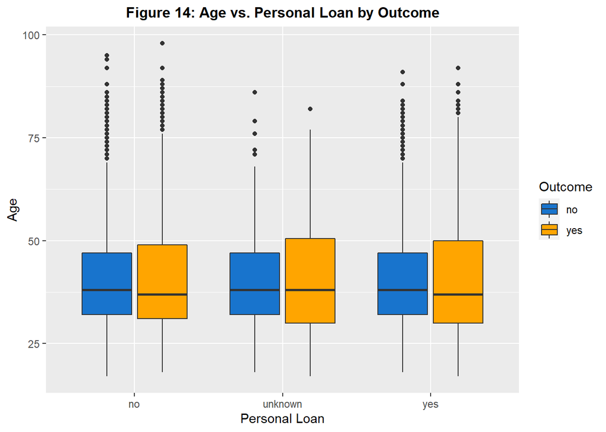

```r
p14 <- ggplot(data, aes(x=loan,y=age, fill=y))
p14+geom_boxplot()+labs(title="Figure 14: Age vs. Personal Loan by Outcome",
                        y="Age",
                        x="Personal Loan",
                        fill="Outcome")+theme(plot.title=element_text(hjust=0.5,face="bold", size=12)) +scale_fill_manual(values=c("dodgerblue3", "orange"))
```

**Figure 14 illustrates the relationship of age and personal loan by the outcome of the marketing campaign. It can be seen that average age across all categories is almost the same at around 37-40 years old. Personal loan also does not affect the result of the outcome.**

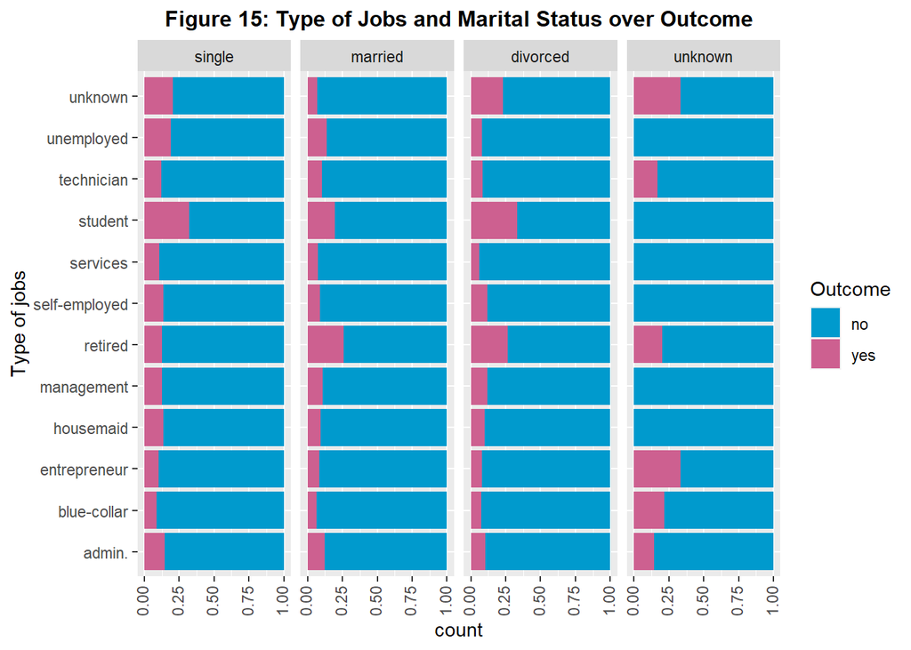

```r
p15 <-ggplot(data, aes(x = job, fill = y)) + geom_bar(position = 'fill') + facet_grid(~marital)

p15  +
  theme(axis.text.x = element_text(angle = 90, vjust=0.3, hjust = 1), plot.title=element_text(hjust=0.5,face="bold", size=12)) +
  labs(title = 'Figure 15: Type of Jobs and Marital Status over Outcome',
       x= "Type of jobs",
       fill="Outcome")+
  scale_fill_manual(values=c("deepskyblue3", "hotpink3"))+
  coord_flip()
```

**Figure 15 indicates that students who are single and divorced subscribe to term deposit more than students who are married. Retired people who are married tend to say yes to the subscription more than retired who are single while single people in other job categories tend to subscribe to the term deposit than married people.**

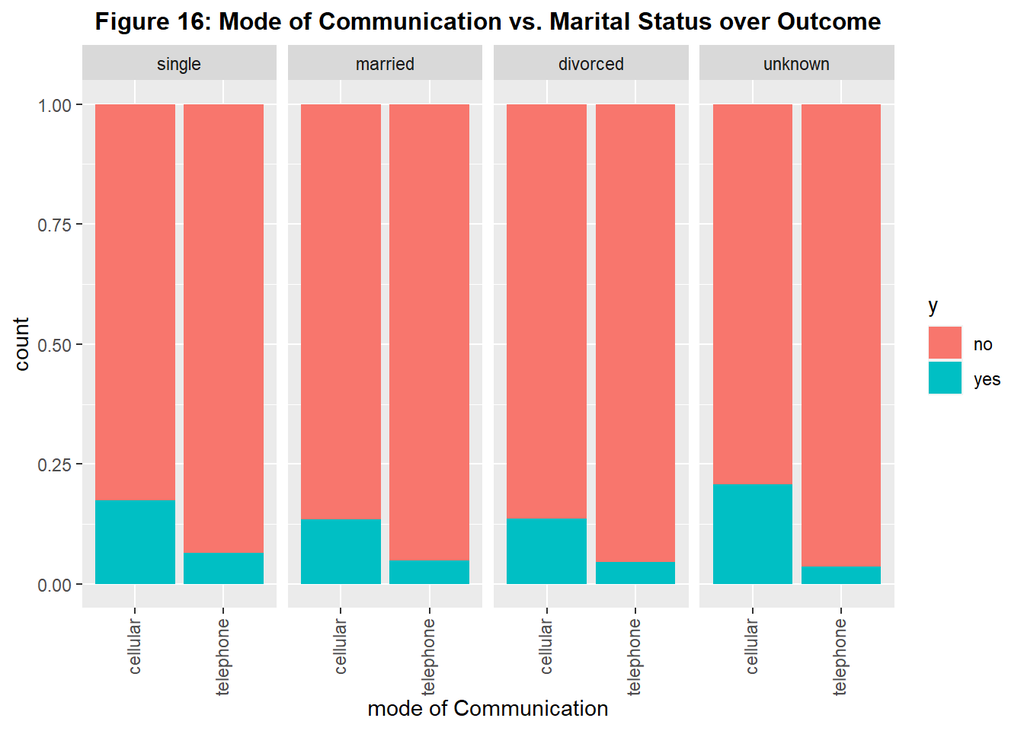

```r
p16 <-ggplot(data, aes(x = contact, fill = y)) + geom_bar(position = 'fill') + facet_grid(~marital)

p16  +
  theme(axis.text.x = element_text(angle = 90, vjust=0.3, hjust = 1), plot.title=element_text(hjust=0.5,face="bold", size=12,)) +
  labs(title = 'Figure 16: Mode of Communication vs. Marital Status over Outcome',
       x="mode of Communication")
```

**Figure 16 shows that using cellular as the type of communication has higher success rate. And for the clients with unknown marital status and single, the proportion of success outcome is higher than others.**

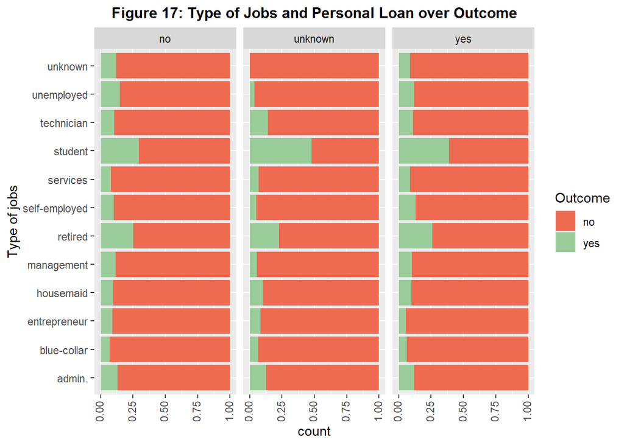

```r
p17 <-ggplot(data, aes(x = job, fill = y)) + geom_bar(position = 'fill') + facet_grid(~loan)

p17  +
  theme(axis.text.x = element_text(angle = 90, vjust=0.3, hjust = 1), plot.title=element_text(hjust=0.5,face="bold", size=12)) +
  labs(title = 'Figure 17: Type of Jobs and Personal Loan over Outcome',
       x= "Type of jobs",
       fill="Outcome")+
  scale_fill_manual(values=c("coral2", "darkseagreen3"))+
  coord_flip()
```

**In Figure 17, students and self-employed with personal loan tend to subscribe to term deposit more than those without personal loan. While the success rate of technicians, retired people, people in management, housemaids and admins are almost the same whether they have personal loan or not.**

## Result and Discussion

Most of clients contacted in the data **were married**, and the result showed **married people tend to subscribe** to term deposit more than others. However, if compared success-failure, single people had higher proportion of the success outcome.

If we look at the outcome of the marketing campaign across **education level, illiterate people followed by unknown education status and university degree has highest proportion in success rate**.

Among job categories, **students and retired agreed to the subscription more than others**. In addition, single and divorced students agreed to subscribed to term deposit more than married students. And retired who were married tended to say yes to the subscription more than retired who were single, while single people in other job categories tended to subscribe to the term deposit than married people. Besides, students and self-employed with personal loan have subscribed to term deposit more than those without personal loan. More interestingly, **mode of communication** did influence the outcome of the campaign. Cellular was proved to have more impact on the success rate.

On the other hand, age distributions of clients who have and have not subscribed to the bank term deposit were the same, meaning **age did not have any effect** on the outcome of the campaign. Furthermore, **housing and Personal loan also did not influence** the outcome of the marketing.

# 6. Statistical Modelling

## Reading the data

Data prepared in the early stage is loaded into the dataframe **data_clean**. The first **ID** column has been removed as it is irrelevant to our analysis. “StringsAsFactors = True” is used to convert the categorical data into factors. We checked the structure of the data to make sure there is nothing odd and all categorical variables are successfully converted to factor.

```r
#Read data in and Remove first column
data_clean <- read.csv("data_clean.csv", stringsAsFactors = TRUE)[,-1]

#Structure
str(data_clean)
```

```
## 'data.frame':    41188 obs. of  20 variables:
##  $ age           : int  56 57 37 40 56 45 59 41 24 25 ...
##  $ job           : Factor w/ 12 levels "admin.","blue-collar",..: 4 8 8 1 8 8 1 2 10 8 ...
##  $ marital       : Factor w/ 4 levels "divorced","married",..: 2 2 2 2 2 2 2 2 3 3 ...
##  $ education     : Factor w/ 8 levels "basic 4y","basic 6y",..: 1 4 4 2 4 3 6 8 6 4 ...
##  $ default       : Factor w/ 3 levels "no","unknown",..: 1 2 1 1 1 2 1 2 1 1 ...
##  $ housing       : Factor w/ 3 levels "no","unknown",..: 1 1 3 1 1 1 1 1 3 3 ...
##  $ loan          : Factor w/ 3 levels "no","unknown",..: 1 1 1 1 3 1 1 1 1 1 ...
##  $ contact       : Factor w/ 2 levels "cellular","telephone": 2 2 2 2 2 2 2 2 2 2 ...
##  $ month         : Factor w/ 10 levels "apr","aug","dec",..: 7 7 7 7 7 7 7 7 7 7 ...
##  $ day_of_week   : Factor w/ 5 levels "fri","mon","thu",..: 2 2 2 2 2 2 2 2 2 2 ...
##  $ campaign      : int  1 1 1 1 1 1 1 1 1 1 ...
##  $ pdays         : Factor w/ 2 levels "Have contacted",..: 2 2 2 2 2 2 2 2 2 2 ...
##  $ previous      : int  0 0 0 0 0 0 0 0 0 0 ...
##  $ poutcome      : Factor w/ 3 levels "failure","nonexistent",..: 2 2 2 2 2 2 2 2 2 2 ...
##  $ emp.var.rate  : num  1.1 1.1 1.1 1.1 1.1 1.1 1.1 1.1 1.1 1.1 ...
##  $ cons.price.idx: num  94 94 94 94 94 ...
##  $ cons.conf.idx : num  -36.4 -36.4 -36.4 -36.4 -36.4 -36.4 -36.4 -36.4 -36.4 -36.4 ...
##  $ euribor3m     : num  4.86 4.86 4.86 4.86 4.86 ...
##  $ nr.employed   : num  5191 5191 5191 5191 5191 ...
##  $ y             : Factor w/ 2 levels "no","yes": 1 1 1 1 1 1 1 1 1 1 ...
```

### Data Modiftication

```r
#subset data to 5000 rows
set.seed(999)
subsetData <- data_clean[sample(nrow(data_clean), 5000), ]

#summary stats
SummaryStats(data_clean)
```

```
## Descriptive Statistics
## x
## N: 41188
##
##                            Min        Q1      Mean    Median        Q3       Max      IQR   Std.Dev
## -------------------- --------- --------- --------- --------- --------- --------- -------- ---------
##                  age     17.00     32.00     40.02     38.00     47.00     98.00    15.00     10.42
##             campaign      1.00      1.00      2.57      2.00      3.00     56.00     2.00      2.77
##        cons.conf.idx    -50.80    -42.70    -40.50    -41.80    -36.40    -26.90     6.30      4.63
##       cons.price.idx     92.20     93.08     93.58     93.75     93.99     94.77     0.92      0.58
##         emp.var.rate     -3.40     -1.80      0.08      1.10      1.40      1.40     3.20      1.57
##            euribor3m      0.63      1.34      3.62      4.86      4.96      5.04     3.62      1.73
##          nr.employed   4963.60   5099.10   5167.04   5191.00   5228.10   5228.10   129.00     72.25
##             previous      0.00      0.00      0.17      0.00      0.00      7.00     0.00      0.49
```

```r
SummaryStats(subsetData)
```

```
## Descriptive Statistics
## x
## N: 5000
##
##                            Min        Q1      Mean    Median        Q3       Max      IQR   Std.Dev
## -------------------- --------- --------- --------- --------- --------- --------- -------- ---------
##                  age     17.00     32.00     40.13     38.00     47.00     88.00    15.00     10.62
##             campaign      1.00      1.00      2.58      2.00      3.00     35.00     2.00      2.72
##        cons.conf.idx    -50.80    -42.70    -40.46    -41.80    -36.40    -26.90     6.30      4.69
##       cons.price.idx     92.20     93.08     93.58     93.88     93.99     94.77     0.92      0.59
##         emp.var.rate     -3.40     -1.80      0.06      1.10      1.40      1.40     3.20      1.59
##            euribor3m      0.64      1.34      3.59      4.86      4.96      4.97     3.62      1.75
##          nr.employed   4963.60   5099.10   5165.29   5191.00   5228.10   5228.10   129.00     73.52
##             previous      0.00      0.00      0.18      0.00      0.00      6.00     0.00      0.50
```

Duplicate rows were checked and removed from the dataset.

```r
#duplicate rows
sum(duplicated(subsetData))
```

```
## [1] 26
```

```r
#remove duplicate rows
subsetData <- unique(subsetData)
sum(duplicated(subsetData))
```

```
## [1] 0
```

## 6.1 Model Fitting

#### Checking the dependant variable

We checked our dependent variable before our analysis to ensure the responses are accurately captured.

```r
contrasts(subsetData$y)
```

```
##     yes
## no    0
## yes   1
```

Here our dependent variable (Y) is binary and the values, **1 is the positive class** which denotes Yes & **0 is the negative class** which denotes No.

#### 6.1.1 Manual Fitting with all variables

```r
#running logistic regression model with all variables
full.fit<-glm(formula = y ~ ., family = binomial(link=logit), data = subsetData)
summary(full.fit) #get NA's for loan unknown because the model has multicollinearity
```

```
##
## Call:
## glm(formula = y ~ ., family = binomial(link = logit), data = subsetData)
##
## Deviance Residuals:
##     Min       1Q   Median       3Q      Max
## -2.0011  -0.4157  -0.3287  -0.2467   2.9302
##
## Coefficients: (1 not defined because of singularities)
##                                 Estimate Std. Error z value Pr(>|z|)
## (Intercept)                   -2.430e+02  9.623e+01  -2.525  0.01156 *
## age                           -1.673e-02  6.092e-03  -2.746  0.00603 **
## jobblue-collar                -1.276e-01  1.987e-01  -0.642  0.52065
## jobentrepreneur                4.229e-02  2.983e-01   0.142  0.88726
## jobhousemaid                  -2.578e-01  3.560e-01  -0.724  0.46893
## jobmanagement                  1.651e-01  2.113e-01   0.781  0.43477
## jobretired                     7.532e-01  2.580e-01   2.920  0.00351 **
## jobself-employed              -1.127e-01  3.031e-01  -0.372  0.70999
## jobservices                   -3.351e-01  2.243e-01  -1.494  0.13511
## jobstudent                    -1.452e-01  2.893e-01  -0.502  0.61567
## jobtechnician                 -2.890e-02  1.768e-01  -0.163  0.87016
## jobunemployed                 -3.995e-02  2.990e-01  -0.134  0.89372
## jobunknown                    -5.265e-01  6.408e-01  -0.822  0.41129
## maritalmarried                 1.747e-02  1.724e-01   0.101  0.91929
## maritalsingle                  8.717e-02  1.962e-01   0.444  0.65685
## maritalunknown                 1.746e+00  1.064e+00   1.641  0.10074
## educationbasic 6y             -6.228e-01  3.036e-01  -2.051  0.04024 *
## educationbasic 9y             -6.972e-01  2.236e-01  -3.118  0.00182 **
## educationhigh school          -4.418e-01  2.116e-01  -2.088  0.03682 *
## educationilliterate            1.737e+00  1.504e+00   1.155  0.24804
## educationprofessional course  -2.079e-01  2.368e-01  -0.878  0.38010
## educationuniversity degree    -3.515e-01  2.152e-01  -1.633  0.10240
## educationunknown              -4.222e-01  2.907e-01  -1.453  0.14631
## defaultunknown                -1.083e-01  1.543e-01  -0.701  0.48302
## housingunknown                -5.151e-01  3.842e-01  -1.341  0.17999
## housingyes                    -1.871e-02  1.025e-01  -0.183  0.85511
## loanunknown                           NA         NA      NA       NA
## loanyes                       -1.052e-01  1.430e-01  -0.736  0.46201
## contacttelephone              -1.347e+00  2.140e-01  -6.295 3.07e-10 ***
## monthaug                       3.490e-01  3.031e-01   1.152  0.24948
```

[output cut: 17 more lines]

```
## emp.var.rate                  -1.742e+00  3.589e-01  -4.853 1.21e-06 ***
## cons.price.idx                 2.347e+00  6.408e-01   3.662  0.00025 ***
## cons.conf.idx                  4.290e-02  2.029e-02   2.114  0.03450 *
## euribor3m                      5.414e-01  3.236e-01   1.673  0.09434 .
## nr.employed                    4.335e-03  7.713e-03   0.562  0.57409
## ---
## Signif. codes:  0 '***' 0.001 '**' 0.01 '*' 0.05 '.' 0.1 ' ' 1
##
## (Dispersion parameter for binomial family taken to be 1)
##
##     Null deviance: 3674.5  on 4973  degrees of freedom
## Residual deviance: 2834.3  on 4923  degrees of freedom
## AIC: 2936.3
##
## Number of Fisher Scoring iterations: 6
```

It is worth noting that from the test results we can infer that the loan variable does not satisfy the multi-collinearity condition of Logistic Regression since it resulted in NA for loan unknown. Therefore, we remove loan feature and refit the model below.

```r
Model1.fit<-glm(formula = y ~ .-loan, family = binomial(link=logit), data = subsetData)
summary(Model1.fit)
```

```
##
## Call:
## glm(formula = y ~ . - loan, family = binomial(link = logit),
##     data = subsetData)
##
## Deviance Residuals:
##     Min       1Q   Median       3Q      Max
## -1.9916  -0.4150  -0.3285  -0.2477   2.9304
##
## Coefficients:
##                                 Estimate Std. Error z value Pr(>|z|)
## (Intercept)                   -2.426e+02  9.622e+01  -2.521 0.011694 *
## age                           -1.671e-02  6.092e-03  -2.743 0.006081 **
## jobblue-collar                -1.233e-01  1.985e-01  -0.621 0.534537
## jobentrepreneur                4.611e-02  2.980e-01   0.155 0.877040
## jobhousemaid                  -2.497e-01  3.557e-01  -0.702 0.482717
## jobmanagement                  1.676e-01  2.111e-01   0.794 0.427398
## jobretired                     7.568e-01  2.578e-01   2.935 0.003334 **
## jobself-employed              -1.188e-01  3.036e-01  -0.391 0.695619
## jobservices                   -3.349e-01  2.243e-01  -1.493 0.135452
## jobstudent                    -1.380e-01  2.889e-01  -0.478 0.632921
## jobtechnician                 -2.545e-02  1.766e-01  -0.144 0.885435
## jobunemployed                 -3.959e-02  2.993e-01  -0.132 0.894792
## jobunknown                    -5.190e-01  6.409e-01  -0.810 0.418074
## maritalmarried                 1.875e-02  1.725e-01   0.109 0.913424
## maritalsingle                  8.782e-02  1.963e-01   0.447 0.654584
## maritalunknown                 1.737e+00  1.061e+00   1.637 0.101547
## educationbasic 6y             -6.200e-01  3.035e-01  -2.043 0.041098 *
## educationbasic 9y             -6.973e-01  2.236e-01  -3.119 0.001818 **
## educationhigh school          -4.388e-01  2.116e-01  -2.074 0.038049 *
## educationilliterate            1.752e+00  1.504e+00   1.165 0.244059
## educationprofessional course  -2.067e-01  2.367e-01  -0.873 0.382630
## educationuniversity degree    -3.498e-01  2.151e-01  -1.626 0.103909
## educationunknown              -4.210e-01  2.908e-01  -1.448 0.147722
## defaultunknown                -1.082e-01  1.544e-01  -0.701 0.483150
## housingunknown                -5.017e-01  3.839e-01  -1.307 0.191233
## housingyes                    -2.243e-02  1.023e-01  -0.219 0.826493
## contacttelephone              -1.347e+00  2.140e-01  -6.294 3.09e-10 ***
## monthaug                       3.462e-01  3.030e-01   1.143 0.253197
## monthdec                      -8.040e-02  4.811e-01  -0.167 0.867268
```

[output cut: 16 more lines]

```
## emp.var.rate                  -1.743e+00  3.588e-01  -4.858 1.18e-06 ***
## cons.price.idx                 2.346e+00  6.407e-01   3.662 0.000251 ***
## cons.conf.idx                  4.286e-02  2.029e-02   2.112 0.034681 *
## euribor3m                      5.453e-01  3.236e-01   1.685 0.091958 .
## nr.employed                    4.252e-03  7.712e-03   0.551 0.581428
## ---
## Signif. codes:  0 '***' 0.001 '**' 0.01 '*' 0.05 '.' 0.1 ' ' 1
##
## (Dispersion parameter for binomial family taken to be 1)
##
##     Null deviance: 3674.5  on 4973  degrees of freedom
## Residual deviance: 2834.8  on 4924  degrees of freedom
## AIC: 2934.8
##
## Number of Fisher Scoring iterations: 6
```

Based on the result of the full fitting, the model is

$$-242.6 - 0.01671 Age + 0.7568 jobretired - 0.62 educationbasic 6y - 0.6973 educationbasic 9y - 0.4388 educationhigh school - 1.347 contacttelephone - 0.5754 monthjun + 1.636 monthmar - 0.3621 monthmay - 0.9391 monthnov + 0.8085 poutcomenonexistent + 1.549 poutcomesuccess - 1.743 emp.var.rate + 2.346 cons.price.idx + 0.04286 cons.conf.idx -0.2946 day_of_weekmon - 0.04708 campaign + 0.5453 euribor3m$$

#### 6.1.2. Feature Selection

In this section, we perform feature selection using Learning Vector Quantization (LVQ) model. The variables are ranked based on its importance. As observed, the first important variable is nr.employed followed by euribor3m, emp.var.rate, contact, cons.price.idx and so on.

```r
library(mlbench)
library(caret)
library(e1071)
# prepare training scheme
control <- trainControl(method="repeatedcv", number=10, repeats=3)
# train the model
model <- train(y~., data=subsetData, method="lvq", preProcess="scale", trControl=control)
# estimate variable importance
importance <- varImp(model, scale=FALSE)
#save.image("featureselection.Rdata")
```

```r
load("featureselection.Rdata")
# summarize importance
print(importance)
# plot importance
plot(importance)
```

[output not shown]

#### 6.1.3 Model Selection

In this section, we will use both genetic search and forward selection to find the best model and compare the two later on. ##### a. Using Genetic Search In order to reduce run time, only the first 15 variables based on its importance found above are included in the model to run genetic search among main effects. Also, we used genetic search over exhaustive search as the latter would analyze 2^15 models resulting in longer computational time.

```r
#Genetic search with 15 features by including ony main effects
startTime = proc.time()
set.seed(999)
main.search <- glmulti(y = y ~ nr.employed + euribor3m + emp.var.rate + contact
                         + cons.price.idx + previous + pdays + poutcome + default
                         + campaign + education + cons.price.idx + marital + age + month,
                         data = subsetData,
                         fitfunction = "glm",
                         level = 1, method = "g",
                         crit ="aicc", family = binomial(link="logit"))

#show elapsed time
stopTime = proc.time()


# save.image(file="Geneticsearchlevel1.RData")
```

```r
load(file="Maingeneticsearch.RData")
elapsedTime = stopTime - startTime
show(elapsedTime)
```

```
##    user  system elapsed
##  762.42    8.72  771.49
```

```r
main.search@formulas[[1]]
```

```
## y ~ 1 + contact + poutcome + education + month + nr.employed +
##     euribor3m + emp.var.rate + cons.price.idx + campaign + age
## <environment: 0x0000000070e44fb0>
```

```r
weightable(main.search)[1:5,]
```

```
##                                                                                                                                 model
## 1           y ~ 1 + contact + poutcome + education + month + nr.employed + euribor3m + emp.var.rate + cons.price.idx + campaign + age
## 2                         y ~ 1 + contact + poutcome + education + month + euribor3m + emp.var.rate + cons.price.idx + campaign + age
## 3 y ~ 1 + contact + poutcome + default + education + month + nr.employed + euribor3m + emp.var.rate + cons.price.idx + campaign + age
## 4                 y ~ 1 + contact + poutcome + education + month + nr.employed + euribor3m + emp.var.rate + cons.price.idx + campaign
## 5               y ~ 1 + contact + poutcome + default + education + month + euribor3m + emp.var.rate + cons.price.idx + campaign + age
##       aicc    weights
## 1 2921.254 0.12186426
## 2 2921.388 0.11396197
## 3 2922.100 0.07983012
## 4 2922.106 0.07959240
## 5 2922.162 0.07738606
```

```r
print(main.search)
```

```
## glmulti.analysis
## Method: g / Fitting: glm / IC used: aicc
## Level: 1 / Marginality: FALSE
## From 100 models:
## Best IC: 2921.25368243175
## Best model:
## [1] "y ~ 1 + contact + poutcome + education + month + nr.employed + "
## [2] "    euribor3m + emp.var.rate + cons.price.idx + campaign + age"
## Evidence weight: 0.121864256054411
## Worst IC: 2945.09438861963
## 8 models within 2 IC units.
## 30 models to reach 95% of evidence weight.
## Convergence after 790 generations.
## Time elapsed: 12.848073498408 minutes.
```

```r
#Best Model from genetic algorithm
Model2.fit <- glm(formula = y ~ contact + poutcome + education + month + nr.employed + euribor3m + emp.var.rate
                  + cons.price.idx + campaign + age,
              family = binomial(link=logit), data = subsetData)

summary(Model2.fit)
```

```
##
## Call:
## glm(formula = y ~ contact + poutcome + education + month + nr.employed +
##     euribor3m + emp.var.rate + cons.price.idx + campaign + age,
##     family = binomial(link = logit), data = subsetData)
##
## Deviance Residuals:
##     Min       1Q   Median       3Q      Max
## -2.0113  -0.4139  -0.3296  -0.2579   2.7583
##
## Coefficients:
##                                Estimate Std. Error z value Pr(>|z|)
## (Intercept)                  -1.068e+02  7.247e+01  -1.474 0.140397
## contacttelephone             -1.133e+00  1.868e-01  -6.064 1.33e-09 ***
## poutcomenonexistent           7.120e-01  1.608e-01   4.427 9.53e-06 ***
## poutcomesuccess               1.806e+00  2.213e-01   8.162 3.29e-16 ***
## educationbasic 6y            -6.499e-01  2.979e-01  -2.181 0.029163 *
## educationbasic 9y            -7.107e-01  2.170e-01  -3.275 0.001056 **
## educationhigh school         -4.229e-01  1.860e-01  -2.274 0.022954 *
## educationilliterate           1.979e+00  1.445e+00   1.370 0.170787
## educationprofessional course -1.678e-01  1.995e-01  -0.841 0.400169
## educationuniversity degree   -2.595e-01  1.772e-01  -1.464 0.143092
## educationunknown             -4.035e-01  2.706e-01  -1.491 0.135978
## monthaug                      4.799e-01  2.950e-01   1.626 0.103848
## monthdec                     -2.242e-01  4.720e-01  -0.475 0.634765
## monthjul                     -4.653e-02  2.266e-01  -0.205 0.837270
## monthjun                     -2.927e-01  2.849e-01  -1.027 0.304231
## monthmar                      1.446e+00  3.513e-01   4.117 3.83e-05 ***
## monthmay                     -4.076e-01  2.003e-01  -2.035 0.041853 *
## monthnov                     -1.051e+00  2.896e-01  -3.628 0.000285 ***
## monthoct                     -4.167e-01  3.734e-01  -1.116 0.264438
## monthsep                     -2.408e-01  4.366e-01  -0.552 0.581265
## nr.employed                  -7.931e-03  5.417e-03  -1.464 0.143186
## euribor3m                     1.037e+00  2.282e-01   4.543 5.54e-06 ***
## emp.var.rate                 -1.584e+00  3.405e-01  -4.651 3.31e-06 ***
## cons.price.idx                1.522e+00  5.046e-01   3.017 0.002552 **
## campaign                     -5.221e-02  2.633e-02  -1.983 0.047337 *
## age                          -7.192e-03  4.256e-03  -1.690 0.091064 .
## ---
## Signif. codes:  0 '***' 0.001 '**' 0.01 '*' 0.05 '.' 0.1 ' ' 1
##
## (Dispersion parameter for binomial family taken to be 1)
##
##     Null deviance: 3674.5  on 4973  degrees of freedom
## Residual deviance: 2869.0  on 4948  degrees of freedom
## AIC: 2921
##
## Number of Fisher Scoring iterations: 6
```

Based on the result of the genetic search, the best model is

$$-106.8 - 1.133 x contacttelephone + 0.7120 x poutcomenonexistent + 1.806 x poutcomesuccess - 0.6499 x educationbasic 6y - 0.7107 x educationbasic 9y - 0.4229 x educationhigh school + 1.446 x monthmar - 0.4076 x monthmay - 1.051 x monthnov + 1.037 x euribor3m - 1.584 x emp.var.rate + 1.522 x cons.price.idx - 0.05221 x campaign - 0.007192 x age$$

##### b. Using Forward Selection

Since it would take enormous amounts of time and processing to run Interaction models in GLMulti function, forward selection is use to to find the best model that include both main effects and interactions.

```r
startTime = proc.time()
set.seed(999)
# first fit the smallest and largest models to be considered
empty.mod <- glm(formula = y ~ 1, family = binomial(link = logit), data = subsetData)
full.mod <- glm(formula = y ~ .^2, family = binomial(link = logit), data = subsetData)

# forward elimination:
forw.sel <- step(object = empty.mod,
                 scope = list(upper = full.mod),
                 direction = "forward",
                 k = 2, trace = TRUE)
#show elapsed time
stopTime = proc.time()
elapsedTime = stopTime - startTime
show(elapsedTime)

save.image(file="forwardselection.RData")
```

```r
load(file="forwardselection.RData")
summary(forw.sel)
```

```
##
## Call:
## glm(formula = y ~ nr.employed + month + poutcome + contact +
##     cons.conf.idx + campaign + education + age + month:contact +
##     nr.employed:contact + poutcome:contact + contact:cons.conf.idx +
##     poutcome:cons.conf.idx + nr.employed:poutcome + campaign:age +
##     cons.conf.idx:campaign, family = binomial(link = logit),
##     data = subsetData)
##
## Deviance Residuals:
##     Min       1Q   Median       3Q      Max
## -2.2255  -0.4114  -0.3242  -0.2418   2.8858
##
## Coefficients:
##                                        Estimate Std. Error z value Pr(>|z|)
## (Intercept)                           6.973e+01  1.507e+01   4.627 3.72e-06 ***
## nr.employed                          -1.333e-02  3.017e-03  -4.417 9.99e-06 ***
## monthaug                              3.990e-02  2.841e-01   0.140 0.888327
## monthdec                             -1.608e-01  4.670e-01  -0.344 0.730628
## monthjul                              4.169e-01  2.493e-01   1.672 0.094448 .
## monthjun                              7.378e-01  2.683e-01   2.750 0.005958 **
## monthmar                              9.927e-01  3.258e-01   3.047 0.002311 **
## monthmay                             -6.793e-01  1.961e-01  -3.465 0.000530 ***
## monthnov                             -4.931e-01  2.612e-01  -1.887 0.059103 .
## monthoct                             -6.396e-01  3.589e-01  -1.782 0.074706 .
## monthsep                             -4.565e-01  3.817e-01  -1.196 0.231692
## poutcomenonexistent                  -6.887e+00  1.586e+01  -0.434 0.664110
## poutcomesuccess                       4.340e+01  2.530e+01   1.715 0.086300 .
## contacttelephone                     -4.354e+01  1.430e+01  -3.044 0.002336 **
## cons.conf.idx                         8.251e-02  2.745e-02   3.006 0.002645 **
## campaign                              4.707e-01  2.702e-01   1.742 0.081538 .
## educationbasic 6y                    -6.498e-01  2.995e-01  -2.170 0.030009 *
## educationbasic 9y                    -7.529e-01  2.206e-01  -3.413 0.000641 ***
## educationhigh school                 -4.201e-01  1.878e-01  -2.237 0.025296 *
## educationilliterate                   1.320e+00  1.615e+00   0.817 0.413752
## educationprofessional course         -2.173e-01  2.028e-01  -1.072 0.283912
## educationuniversity degree           -3.091e-01  1.801e-01  -1.716 0.086082 .
## educationunknown                     -5.439e-01  2.793e-01  -1.948 0.051440 .
## age                                   1.829e-04  6.675e-03   0.027 0.978142
## monthaug:contacttelephone            -2.282e+00  1.220e+00  -1.870 0.061494 .
```

[output cut: 13 more lines]

```
## poutcomesuccess:cons.conf.idx        -9.647e-02  3.630e-02  -2.658 0.007871 **
## nr.employed:poutcomenonexistent       8.118e-04  3.194e-03   0.254 0.799397
## nr.employed:poutcomesuccess          -9.022e-03  5.067e-03  -1.781 0.074985 .
## campaign:age                         -4.164e-03  2.662e-03  -1.564 0.117713
## cons.conf.idx:campaign                8.844e-03  5.832e-03   1.516 0.129396
## ---
## Signif. codes:  0 '***' 0.001 '**' 0.01 '*' 0.05 '.' 0.1 ' ' 1
##
## (Dispersion parameter for binomial family taken to be 1)
##
##     Null deviance: 3674.5  on 4973  degrees of freedom
## Residual deviance: 2787.3  on 4931  degrees of freedom
## AIC: 2873.3
##
## Number of Fisher Scoring iterations: 12
```

The procedure of forward selection takes about 7 minutes to complete, which is much quicker than the genetic search and the result also includes interactions between some variables. The best model selected by this method is:

$$69.73 - 0.01333 x nr.employed + 0.4169 x monthjul + 0.7378 x monthjun + 0.9927 x monthmar - 0.6793 x monthmay - 0.4931 x monthnov - 0.6396 x monthoct + 43.40 x poutcomesuccess - 43.54 x contacttelephone + 0.08251 x cons.conf.idx + 0.4707 x campaign - 0.3091 x
educationuniversity degree - 0.5439 x educationunknown - 2.282 x monthaug:contacttelephone -0.6.498 x educationbasic 6y - 0.7529 x educationbasic 9y - 0.4201 x educationhigh school - 3.214 x monthjul:contacttelephone - 2.242 x monthjun:contacttelephone - 6.314 x monthmar:contacttelephone - 2.571 x monthmay:contacttelephone - 5.064 x monthsep:contacttelephone + 0.01067 x nr.employed:contacttelephone + 3.259 x poutcomesuccess:contacttelephone + 0.2460 x contacttelephone:cons.conf.idx - 0.08937 x poutcomenonexistent:cons.conf.idx - 0.09647 x poutcomesuccess:cons.conf.idx - 0.009022 x nr.employed:poutcomesuccess$$

### 6.1.4 Model Evaluation

AIC, AICc and BIC are used to compare the three fitted models above. Based on the result, the three criteria do not agree on the best model. The model chosen by forward selection has the lowest AIC (2873.348) and AICc (2874.115) while the model chosen by genetic search has the lowest BIC (3090.281). That is because BIC tends toward smaller model, so it prefers the second model. Because both AIC and AICc agrees on the third model, which includes both main effects and interactions and the model has the second lowest BIC, we choose that model as the best one among all.

```r
#AICC and BIC
AICc <- function(object) {
  n <- length(object$y)
  r <- length(object$coefficients)
  AIC <- round(AIC(object),3)
  AICc <- round(AIC(object) + 2*r*(r + 1)/(n - r - 1),3)
  BIC <- round(BIC(object),3)
  list(AIC= AIC,AICc = AICc, BIC = BIC)
}

Model_Values <- rbind(transpose(AICc(Model1.fit))[[1]],transpose(AICc(Model2.fit))[[1]],transpose(AICc(forw.sel))[[1]])

Model_Name <- c("Full Model Fit","Generic Search Fit ","Forward Selection Fit")

Model_Evaluation <- data.frame(Model_Name, Model_Values)
colnames(Model_Evaluation) <- c("Model Name","AIC","AICc","BIC")
Model_Evaluation
```

```
##              Model Name      AIC     AICc      BIC
## 1        Full Model Fit  2934.85 2935.885 3260.448
## 2   Generic Search Fit   2920.97 2921.254 3090.281
## 3 Forward Selection Fit 2873.348 2874.115 3153.363
```

## 6.2 Residual Analysis

It is always easier to analyze the data in explanatory variable pattern (EVP) form when evaluating how well a model for this type of response matches the data. For each of the unique sets of independent variables, this aggregated format has one row in the data set.

Before evaluating the fit of the model, we converted the dataset to EVP form.

```r
# EVP Form
subsetData1 <- subsetData %>% mutate (y =  if_else(subsetData$y=="no",0,1))
w <- aggregate(formula = y ~ nr.employed + month + poutcome + contact + cons.conf.idx + campaign + education + age + month:contact
               + nr.employed:contact + poutcome:contact + contact:cons.conf.idx + poutcome:cons.conf.idx + nr.employed:poutcome + campaign:age
               + cons.conf.idx:campaign,
               data = subsetData1, FUN = sum)
n <- aggregate(formula = y ~ nr.employed + month + poutcome + contact + cons.conf.idx + campaign + education + age + month:contact
               + nr.employed:contact + poutcome:contact + contact:cons.conf.idx + poutcome:cons.conf.idx + nr.employed:poutcome + campaign:age
               + cons.conf.idx:campaign,
               data = subsetData, FUN = length)

w.n <- data.frame(w, trials = n$y, prop = round(w$y/n$y, 4))
head(w.n)
```

```
##   nr.employed month    poutcome   contact cons.conf.idx campaign education age
## 1      5076.2   aug     failure  cellular         -31.4        2  basic 9y  17
## 2      5076.2   aug     success  cellular         -31.4        3  basic 9y  17
## 3      4991.6   jun nonexistent  cellular         -39.8        1  basic 4y  18
## 4      5008.7   may     success telephone         -40.0        1   unknown  18
## 5      4991.6   aug     failure  cellular         -38.3        1   unknown  18
## 6      5017.5   sep nonexistent  cellular         -29.8        2   unknown  18
##   y trials prop
## 1 1      1    1
## 2 0      1    0
## 3 0      1    0
## 4 1      1    1
## 5 1      1    1
## 6 0      1    0
```

```r
nrow(w.n)
```

```
## [1] 3684
```

```r
sum(w.n$trials)
```

```
## [1] 4974
```

We run the best model in EVP form, because statistical tests that analyse how well the model fits the data, work better with EVP form.

```r
mod.prelim1 <- glm(formula =y/trials ~ nr.employed + month + poutcome + contact + cons.conf.idx + campaign + education + age + month:contact
               + nr.employed:contact + poutcome:contact + contact:cons.conf.idx + poutcome:cons.conf.idx + nr.employed:poutcome + campaign:age
               + cons.conf.idx:campaign,
                   family = binomial(link = logit), data = w.n, weights =
                     trials)
summary(mod.prelim1) #same results
```

```
##
## Call:
## glm(formula = y/trials ~ nr.employed + month + poutcome + contact +
##     cons.conf.idx + campaign + education + age + month:contact +
##     nr.employed:contact + poutcome:contact + contact:cons.conf.idx +
##     poutcome:cons.conf.idx + nr.employed:poutcome + campaign:age +
##     cons.conf.idx:campaign, family = binomial(link = logit),
##     data = w.n, weights = trials)
##
## Deviance Residuals:
##     Min       1Q   Median       3Q      Max
## -2.2255  -0.5029  -0.3398  -0.2234   2.8858
##
## Coefficients:
##                                        Estimate Std. Error z value Pr(>|z|)
## (Intercept)                           6.973e+01  1.507e+01   4.627 3.72e-06 ***
## nr.employed                          -1.333e-02  3.017e-03  -4.417 9.99e-06 ***
## monthaug                              3.990e-02  2.841e-01   0.140 0.888327
## monthdec                             -1.608e-01  4.670e-01  -0.344 0.730628
## monthjul                              4.169e-01  2.493e-01   1.672 0.094448 .
## monthjun                              7.378e-01  2.683e-01   2.750 0.005958 **
## monthmar                              9.927e-01  3.258e-01   3.047 0.002311 **
## monthmay                             -6.793e-01  1.961e-01  -3.465 0.000530 ***
## monthnov                             -4.931e-01  2.612e-01  -1.887 0.059103 .
## monthoct                             -6.396e-01  3.589e-01  -1.782 0.074706 .
## monthsep                             -4.565e-01  3.817e-01  -1.196 0.231692
## poutcomenonexistent                  -6.887e+00  1.586e+01  -0.434 0.664110
## poutcomesuccess                       4.340e+01  2.530e+01   1.715 0.086300 .
## contacttelephone                     -4.354e+01  1.430e+01  -3.044 0.002336 **
## cons.conf.idx                         8.251e-02  2.745e-02   3.006 0.002645 **
## campaign                              4.707e-01  2.702e-01   1.742 0.081538 .
## educationbasic 6y                    -6.498e-01  2.995e-01  -2.170 0.030009 *
## educationbasic 9y                    -7.529e-01  2.206e-01  -3.413 0.000641 ***
## educationhigh school                 -4.201e-01  1.878e-01  -2.237 0.025296 *
## educationilliterate                   1.320e+00  1.615e+00   0.817 0.413752
## educationprofessional course         -2.173e-01  2.028e-01  -1.072 0.283912
## educationuniversity degree           -3.091e-01  1.801e-01  -1.716 0.086082 .
## educationunknown                     -5.439e-01  2.793e-01  -1.948 0.051440 .
## age                                   1.829e-04  6.675e-03   0.027 0.978142
## monthaug:contacttelephone            -2.282e+00  1.220e+00  -1.870 0.061494 .
```

[output cut: 13 more lines]

```
## poutcomesuccess:cons.conf.idx        -9.647e-02  3.630e-02  -2.658 0.007871 **
## nr.employed:poutcomenonexistent       8.118e-04  3.194e-03   0.254 0.799397
## nr.employed:poutcomesuccess          -9.022e-03  5.067e-03  -1.781 0.074985 .
## campaign:age                         -4.164e-03  2.662e-03  -1.564 0.117713
## cons.conf.idx:campaign                8.844e-03  5.832e-03   1.516 0.129396
## ---
## Signif. codes:  0 '***' 0.001 '**' 0.01 '*' 0.05 '.' 0.1 ' ' 1
##
## (Dispersion parameter for binomial family taken to be 1)
##
##     Null deviance: 3188.3  on 3683  degrees of freedom
## Residual deviance: 2301.1  on 3641  degrees of freedom
## AIC: 2603.7
##
## Number of Fisher Scoring iterations: 12
```

We obtained the same parameter estimates as before. However, Null deviance, residual deviance and the AIC values are much lower.

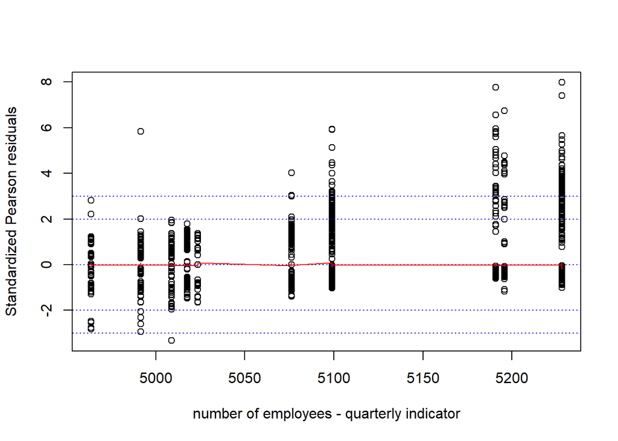

```r
s.res <- rstandard(model = mod.prelim1, type = "pearson")

plot(x = w.n$nr.employed, y = s.res, ylim = c(min(-3, s.res), max(3, s.res)), ylab =
       "Standardized Pearson residuals", xlab = "number of employees - quarterly indicator")

abline(h = c(3, 2, 0, -2, -3), lty = "dotted", col = "blue")
smooth.stand <- loess(formula = s.res ~ campaign, data = w.n, weights = trials)
# Make sure that loess estimates are ordered by "X" for the plots, so that they are displayed properly
order <- order(w.n$nr.employed)
lines(x = w.n$nr.employed[order], y = predict(smooth.stand)[order], lty = "solid", col = "red", lwd = 1)
```

For scatter plot of number of employees vs. standardized residuals, we can see there is only a few points out of lower bound +-2 at smaller value of number of employess. However, as the number of employees gets to 5100 and larger, there are a lot more points get out of upper bound (larger than 3).

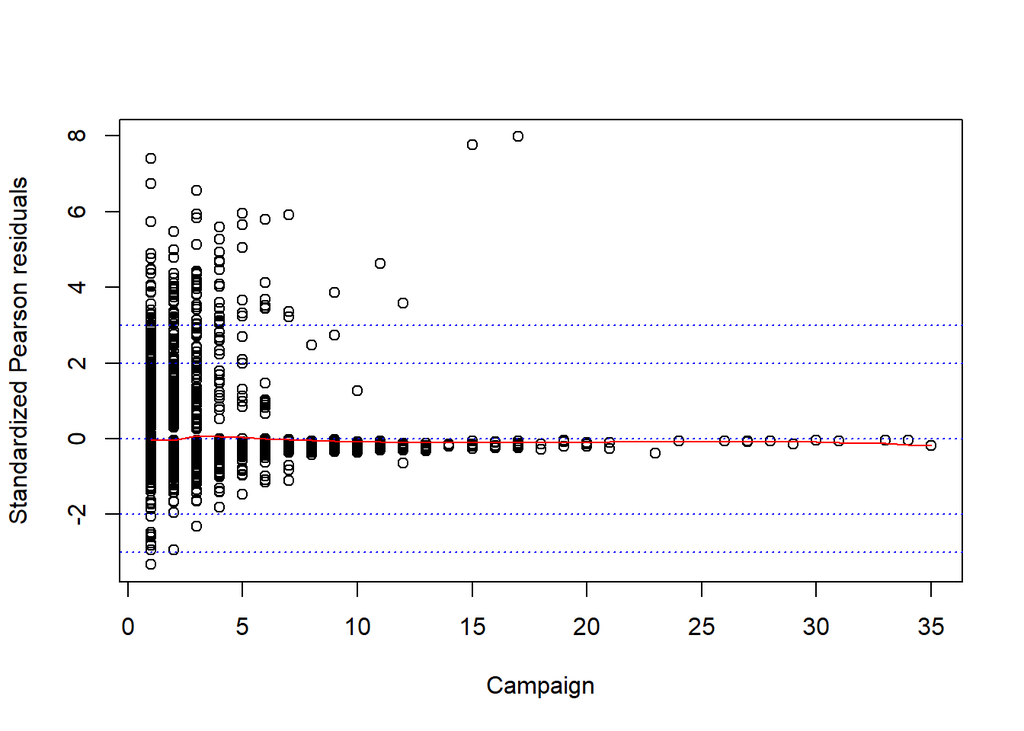

```r
s.res <- rstandard(model = mod.prelim1, type = "pearson")

plot(x = w.n$campaign, y = s.res, ylim = c(min(-3, s.res), max(3, s.res)), ylab =
       "Standardized Pearson residuals", xlab = "Campaign")

abline(h = c(3, 2, 0, -2, -3), lty = "dotted", col = "blue")
smooth.stand <- loess(formula = s.res ~ campaign, data = w.n, weights = trials)
# Make sure that loess estimates are ordered by "X" for the plots, so that they are displayed properly
order <- order(w.n$campaign)
lines(x = w.n$campaign[order], y = predict(smooth.stand)[order], lty = "solid", col = "red", lwd = 1)
```

For the residual plot of campaign (number of called peformed during this campaign) shows that the residuals are dispersed at the lower values and get out of bound +-3, especially the upper bound. But at the higher number of called performed, all the residuals tend gather around 0 and follow the straigh red line.

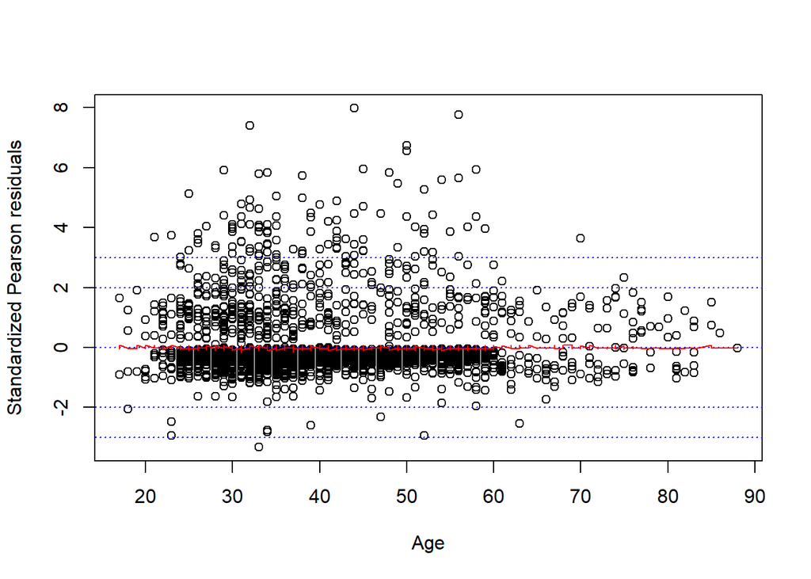

```r
s.res <- rstandard(model = mod.prelim1, type = "pearson")

plot(x = w.n$age, y = s.res, ylim = c(min(-3, s.res), max(3, s.res)), ylab =
       "Standardized Pearson residuals", xlab = "Age")

abline(h = c(3, 2, 0, -2, -3), lty = "dotted", col = "blue")
smooth.stand <- loess(formula = s.res ~ campaign, data = w.n, weights = trials)
# Make sure that loess estimates are ordered by "X" for the plots, so that they are displayed properly
order <- order(w.n$age)
lines(x = w.n$age[order], y = predict(smooth.stand)[order], lty = "solid", col = "red", lwd = 1)
```

The residuals of age feature stays quite well within the lower bound of -3, but get quite far out of upper bound of 3. However, as observed, most of the residuals are gathered around 0 and follow the straight line.

[figure not shown]

```r
s.res <- rstandard(model = mod.prelim1, type = "pearson")

plot(x = w.n$age, y = s.res, ylim = c(min(-3, s.res), max(3, s.res)), ylab =
       "Standardized Pearson residuals", xlab = "Age")

abline(h = c(3, 2, 0, -2, -3), lty = "dotted", col = "blue")
smooth.stand <- loess(formula = s.res ~ campaign, data = w.n, weights = trials)
# Make sure that loess estimates are ordered by "X" for the plots, so that they are displayed properly
order <- order(w.n$age)
lines(x = w.n$age[order], y = predict(smooth.stand)[order], lty = "solid", col = "red", lwd = 1)
```

Since the residual of numerical features that we explore above do not meet the criteria, this may suggest a transformation is needed. Thus, we tend to explore the model with squared of the four numeric features. The fitted model results in AIC of 2870.1, which is a bit lower than the previous model. However, among the added squared terms, only squared $age$ has a significant coefficient. Therefore, we will refit the model with other three squared terms eliminated.

```r
Model4.fit <- glm(formula = y ~ nr.employed + month + poutcome + contact + cons.conf.idx + campaign + education + age
                  + month:contact + nr.employed:contact + poutcome:contact + contact:cons.conf.idx + poutcome:cons.conf.idx
                  + nr.employed:poutcome + campaign:age + cons.conf.idx:campaign
                  + I(nr.employed^2) + I(cons.conf.idx^2) + I(campaign^2) + I(age^2),
              family = binomial(link=logit), data = subsetData)

summary(Model4.fit)
```

```
##
## Call:
## glm(formula = y ~ nr.employed + month + poutcome + contact +
##     cons.conf.idx + campaign + education + age + month:contact +
##     nr.employed:contact + poutcome:contact + contact:cons.conf.idx +
##     poutcome:cons.conf.idx + nr.employed:poutcome + campaign:age +
##     cons.conf.idx:campaign + I(nr.employed^2) + I(cons.conf.idx^2) +
##     I(campaign^2) + I(age^2), family = binomial(link = logit),
##     data = subsetData)
##
## Deviance Residuals:
##     Min       1Q   Median       3Q      Max
## -2.1754  -0.4076  -0.3196  -0.2419   2.9512
##
## Coefficients:
##                                        Estimate Std. Error z value Pr(>|z|)
## (Intercept)                          -2.005e+02  4.317e+02  -0.465 0.642285
## nr.employed                           9.327e-02  1.691e-01   0.552 0.581213
## monthaug                              1.140e-01  3.223e-01   0.354 0.723628
## monthdec                             -7.690e-02  4.864e-01  -0.158 0.874384
## monthjul                              4.792e-01  3.027e-01   1.583 0.113484
## monthjun                              7.432e-01  3.030e-01   2.453 0.014185 *
## monthmar                              9.291e-01  3.359e-01   2.766 0.005674 **
## monthmay                             -6.933e-01  1.996e-01  -3.474 0.000513 ***
## monthnov                             -4.263e-01  3.009e-01  -1.417 0.156577
## monthoct                             -5.547e-01  5.291e-01  -1.048 0.294514
## monthsep                             -3.423e-01  4.453e-01  -0.769 0.442090
## poutcomenonexistent                  -1.148e+01  1.750e+01  -0.656 0.511801
## poutcomesuccess                       4.359e+01  2.556e+01   1.705 0.088122 .
## contacttelephone                     -4.252e+01  1.448e+01  -2.936 0.003321 **
## cons.conf.idx                         9.740e-02  2.298e-01   0.424 0.671666
## campaign                              4.780e-01  2.884e-01   1.657 0.097461 .
## educationbasic 6y                    -5.930e-01  3.031e-01  -1.957 0.050398 .
## educationbasic 9y                    -7.051e-01  2.242e-01  -3.145 0.001661 **
## educationhigh school                 -3.798e-01  1.917e-01  -1.981 0.047619 *
## educationilliterate                   1.454e+00  1.598e+00   0.910 0.362892
## educationprofessional course         -1.540e-01  2.068e-01  -0.745 0.456516
## educationuniversity degree           -2.303e-01  1.847e-01  -1.247 0.212467
## educationunknown                     -5.305e-01  2.840e-01  -1.868 0.061799 .
## age                                  -7.756e-02  2.518e-02  -3.080 0.002070 **
```

[output cut: 18 more lines]

```
## poutcomesuccess:cons.conf.idx        -9.651e-02  3.653e-02  -2.642 0.008240 **
## nr.employed:poutcomenonexistent       1.775e-03  3.536e-03   0.502 0.615791
## nr.employed:poutcomesuccess          -9.055e-03  5.119e-03  -1.769 0.076929 .
## campaign:age                         -3.181e-03  2.735e-03  -1.163 0.244754
## cons.conf.idx:campaign                9.270e-03  5.984e-03   1.549 0.121343
## ---
## Signif. codes:  0 '***' 0.001 '**' 0.01 '*' 0.05 '.' 0.1 ' ' 1
##
## (Dispersion parameter for binomial family taken to be 1)
##
##     Null deviance: 3674.5  on 4973  degrees of freedom
## Residual deviance: 2776.1  on 4927  degrees of freedom
## AIC: 2870.1
##
## Number of Fisher Scoring iterations: 12
```

The last model has the AIC of 2864.9, which is the lowest among the fitted models.

```r
Model5.fit <- glm(formula = y ~ nr.employed + month + poutcome + contact + cons.conf.idx + campaign + education + age
                  + month:contact + nr.employed:contact + poutcome:contact + contact:cons.conf.idx + poutcome:cons.conf.idx
                  + nr.employed:poutcome + campaign:age + cons.conf.idx:campaign
                  + I(age^2),
              family = binomial(link=logit), data = subsetData)

summary(Model5.fit)
```

```
##
## Call:
## glm(formula = y ~ nr.employed + month + poutcome + contact +
##     cons.conf.idx + campaign + education + age + month:contact +
##     nr.employed:contact + poutcome:contact + contact:cons.conf.idx +
##     poutcome:cons.conf.idx + nr.employed:poutcome + campaign:age +
##     cons.conf.idx:campaign + I(age^2), family = binomial(link = logit),
##     data = subsetData)
##
## Deviance Residuals:
##     Min       1Q   Median       3Q      Max
## -2.2050  -0.4096  -0.3191  -0.2425   2.8657
##
## Coefficients:
##                                        Estimate Std. Error z value Pr(>|z|)
## (Intercept)                           6.763e+01  1.520e+01   4.450 8.59e-06 ***
## nr.employed                          -1.263e-02  3.049e-03  -4.144 3.41e-05 ***
## monthaug                              9.436e-03  2.849e-01   0.033 0.973577
## monthdec                             -1.680e-01  4.695e-01  -0.358 0.720499
## monthjul                              3.552e-01  2.504e-01   1.419 0.155908
## monthjun                              6.996e-01  2.693e-01   2.598 0.009374 **
## monthmar                              8.982e-01  3.270e-01   2.747 0.006016 **
## monthmay                             -6.929e-01  1.967e-01  -3.522 0.000428 ***
## monthnov                             -5.233e-01  2.622e-01  -1.996 0.045985 *
## monthoct                             -6.596e-01  3.604e-01  -1.830 0.067227 .
## monthsep                             -4.941e-01  3.827e-01  -1.291 0.196748
## poutcomenonexistent                  -6.362e+00  1.596e+01  -0.399 0.690220
## poutcomesuccess                       4.304e+01  2.537e+01   1.696 0.089825 .
## contacttelephone                     -4.264e+01  1.438e+01  -2.966 0.003019 **
## cons.conf.idx                         7.785e-02  2.783e-02   2.797 0.005162 **
## campaign                              4.244e-01  2.698e-01   1.573 0.115750
## educationbasic 6y                    -5.853e-01  3.028e-01  -1.933 0.053281 .
## educationbasic 9y                    -7.000e-01  2.240e-01  -3.125 0.001781 **
## educationhigh school                 -3.753e-01  1.917e-01  -1.958 0.050267 .
## educationilliterate                   1.498e+00  1.585e+00   0.945 0.344495
## educationprofessional course         -1.480e-01  2.067e-01  -0.716 0.474016
## educationuniversity degree           -2.304e-01  1.848e-01  -1.247 0.212471
## educationunknown                     -5.331e-01  2.847e-01  -1.872 0.061177 .
## age                                  -7.804e-02  2.511e-02  -3.108 0.001883 **
## I(age^2)                              8.287e-04  2.577e-04   3.216 0.001302 **
```

[output cut: 14 more lines]

```
## poutcomesuccess:cons.conf.idx        -9.657e-02  3.652e-02  -2.644 0.008186 **
## nr.employed:poutcomenonexistent       7.213e-04  3.216e-03   0.224 0.822526
## nr.employed:poutcomesuccess          -8.947e-03  5.082e-03  -1.761 0.078315 .
## campaign:age                         -3.008e-03  2.614e-03  -1.151 0.249759
## cons.conf.idx:campaign                8.749e-03  5.830e-03   1.501 0.133451
## ---
## Signif. codes:  0 '***' 0.001 '**' 0.01 '*' 0.05 '.' 0.1 ' ' 1
##
## (Dispersion parameter for binomial family taken to be 1)
##
##     Null deviance: 3674.5  on 4973  degrees of freedom
## Residual deviance: 2776.9  on 4930  degrees of freedom
## AIC: 2864.9
##
## Number of Fisher Scoring iterations: 12
```

```r
BIC(Model5.fit)
```

```
## [1] 3151.407
```

Hence, the final model is > 67.63 - 0.01262 x nr.employed + 0.6996 x monthjun + 0.8982 x monthmar - 0.6929 x monthmay - 0.5233 x monthnov - 0.6596 x monthoct + 43.04 x poutcomesuccess - 42.64 x contacttelephone + 0.07785 x cons.conf.idx - 0.5853 x educationbasic 6y - 0.7 x educationbasic 9y - 0.3753 x educationhigh school - 0.5.331 x educationunknown - 0.07804 x age + 0.0008287 x age^2 - 2.210 x monthaug:contacttelephone - 3.072 x monthjul:contacttelephone - 2.160 x monthjun:contacttelephone - 5.928 x monthmar:contacttelephone - 2.453 x monthmay:contacttelephone - 4.946 x monthsep:contacttelephone + 0.01045 x nr.employed:contacttelephone + 3.093 x poutcomesuccess:contacttelephone + 0.2416 x contacttelephone:cons.conf.idx - 0.0878 x poutcomenonexistent:cons.conf.idx - 0.09657 x poutcomesuccess:cons.conf.idx - 0.008947 x nr.employed:poutcomesuccess

## 6.3 Response Analysis

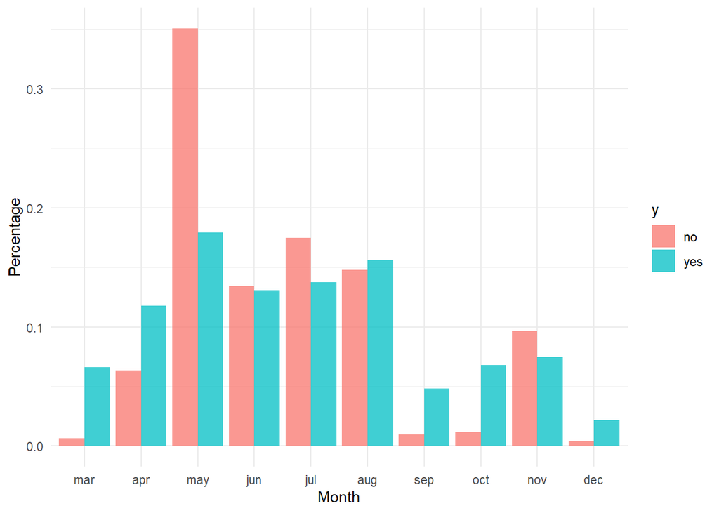

```r
#Analyzing for Month
month <- table(subsetData$month, subsetData$y)
month_tab <- as.data.frame(prop.table(month, 2))
colnames(month_tab) <-  c("Month", "y", "Percentage")

month_tab$Month <- factor(month_tab$Month,levels=c("mar","apr","may","jun","jul","aug","sep","oct","nov","dec"))

ggplot(month_tab, aes(x=Month, y=Percentage, fill=y)) +
  geom_bar(stat="identity",position = position_dodge(), alpha = 0.75)+theme_minimal()+
  xlab("Month")+
  ylab("Percentage")
```

## 6.4 Goodness of Fit

GoF describes how well it fits a set of observations.

```r
rdev <- Model5.fit$deviance # this is the residual deviance
rdev
```

```
## [1] 2776.88
```

```r
dfr <- Model5.fit$df.residual # this is the residual degrees of freedom
dfr
```

```
## [1] 4930
```

```r
ddf <- rdev/dfr
ddf
```

```
## [1] 0.5632617
```

```r
thresh2 <- 1 + 2*sqrt(2/dfr) # Potential problem
thresh3 <- 1 + 3*sqrt(2/dfr)

gof <-c(ddf, thresh2, thresh3) # Good fit
names(gof) <- c("Residual deviance/Df","Threshold2","Threshold3")
gof
```

```
## Residual deviance/Df           Threshold2           Threshold3
##            0.5632617            1.0402830            1.0604245
```

Residual deviance/df is less than both $1+ 2\sqrt{2/df}$ and $1+ 3\sqrt{2/df}$

This indicates that model 5 has good fit, meaning the discrepancy between the observed values and the values expected under this model is very low.

## 6.5 Confidence Interval

```r
# Confidence Interval for age =50
predict.data<-data.frame(age = 50)

alpha<-0.05
pred<-predict(object = glm(formula = y ~ age,
              family = binomial(link=logit), data = subsetData), newdata = predict.data, type = "link", se = TRUE)
pred
```

```
## $fit
##         1
## -1.919729
##
## $se.fit
## [1] 0.05738275
##
## $residual.scale
## [1] 1
```

```r
pi.hat<-exp(pred$fit)/(1+exp(pred$fit))
pi.hat
```

```
##         1
## 0.1278918
```

```r
CI.link <-pred$fit + qnorm(p = c(alpha/2, 1-alpha/2))*pred$se
CI.link
```

```
## [1] -2.032197 -1.807260
```

```r
CI.pi<-exp(CI.link)/(1+exp(CI.link))
CI.pi
```

```
## [1] 0.1158637 0.1409696
```

```r
round(data.frame(predict.data, pi.hat, lower = CI.pi[1], upper = CI.pi[2]),4)
```

```
##   age pi.hat  lower upper
## 1  50 0.1279 0.1159 0.141
```

## 6.6 Hypothesis Tests

From previous section, we have got our final model from previous section as follows.

logit ($\pi$) = $\beta_0$ + $\beta_1$ nr.employed + $\beta_2$ month + $\beta_3$ poutcome + $\beta_4$ contact + $\beta_5$ cons.conf.idx + $\beta_6$ campaign + $\beta_7$ education + $\beta_8$ age + $\beta_9$ month:contact + $\beta_10$ nr.employed:contact + $\beta_11$ poutcome:contact + $\beta_12$ contact:cons.conf.idx + $\beta_13$ poutcome:cons.conf.idx + $\beta_14$ nr.employed:poutcome + $\beta_15$ campaign:age + $\beta_16$ cons.conf.idx:campaign $$

In this section, we perform hypothesis test on parameters of this final model as we are skeptical if campaign variable (number of calls performed during the campaign) really have interaction with other variables in the model. Therefore, there are 2 hypothesis tests to be performed here.

Hypothesis Test 1: H_0: $\beta15$ = 0 $$ H_a: $\beta15$ != 0

Hypothesis Test 2: H_0: $\beta16$ = 0 $$ H_a: $\beta16$ != 0

```r
Anova(Model5.fit, test="LR")
```

```
## Analysis of Deviance Table (Type II tests)
##
## Response: y
##                        LR Chisq Df Pr(>Chisq)
## nr.employed             122.607  1  < 2.2e-16 ***
## month                    74.311  9  2.161e-12 ***
## poutcome                 70.543  2  4.806e-16 ***
## contact                  36.677  1  1.394e-09 ***
## cons.conf.idx             7.582  1  0.0058968 **
## campaign                  3.654  1  0.0559408 .
## education                16.135  7  0.0239093 *
## age                      13.570  1  0.0002298 ***
## I(age^2)                 10.467  1  0.0012151 **
## month:contact            41.834  9  3.525e-06 ***
## nr.employed:contact      15.572  1  7.943e-05 ***
## poutcome:contact         14.245  2  0.0008068 ***
## contact:cons.conf.idx    16.937  1  3.864e-05 ***
## poutcome:cons.conf.idx   12.366  2  0.0020645 **
## nr.employed:poutcome      5.666  2  0.0588380 .
## campaign:age              1.366  1  0.2425264
## cons.conf.idx:campaign    2.299  1  0.1294605
## ---
## Signif. codes:  0 '***' 0.001 '**' 0.01 '*' 0.05 '.' 0.1 ' ' 1
```

Based on the result of Anova test, $\beta_15$ has $-2log(\Lambda)$ = 1.366 and a p-value of 0.2425264, which is larger than 0.05. Thus, it is not statistically significant at 5% significance level. That means we fail to reject the null hypothesis that $\beta_15 = 0$.

Moreover, $\beta_16$ has $-2log(\Lambda)$ = 2.299 and a p-value of 0.1294605 (> 0.05); hence, there is not statistically significant either. That suggests there is not enough evidence to reject the null hypotheis.

From the result of the test, both interactions of campaign:age and cons.conf.idx:campaign can be removed from the final model, which has already been reflected in the formula of the final model.

## 6.7 Sensitivity Analysis

```r
OR <- data.frame("Odd_Ratio" = c(exp(Model5.fit$coefficients[8]), exp(Model5.fit$coefficients[14]), exp(Model5.fit$coefficients[15])
                                 , exp(Model5.fit$coefficients[24])),
                 "1/OR" =  c(1/exp(Model5.fit$coefficients[8]), 1/exp(Model5.fit$coefficients[14]), 1/exp(Model5.fit$coefficients[15])
                             , 1/exp(Model5.fit$coefficients[24])))
colnames(OR) <- c("Odd Ratio","1/Odd Ratio")
OR
```

```
##                     Odd Ratio  1/Odd Ratio
## monthmay         5.001425e-01 1.999430e+00
## contacttelephone 3.040280e-19 3.289171e+18
## cons.conf.idx    1.080956e+00 9.251066e-01
## age              9.249261e-01 1.081167e+00
```

From the displayed result, the odd ratio of monthmay is 0.5, which means if the last contact was in May, the odd of success will decrease about 0.5 time or the odd of failure will increase about 2 times. Moreover, the odd ratio of contacttelephone is 3.04x10^-19 meaning if the communication type was telephone, the odd of of failure will increase 3.28x10^18, which is very high.

# 7. Critique & Limitations

The analysis is quite thorough since we fitted 3 different models including manual fitting including all features except loan, genetic search of all main effects and forward selection. The three models were compared based on AIC, AICc and BIC scores. The best model chosen has the lowest AIC and AICc value, and it includes both main effects and interactions. The best fitted model was selected by forward selection method, which took about 7 minutes to run. It is quite reasonable. The result of goodness of fit also indicates this is a good model for the data.

The limitation of the analysis is AIC, AICc and BIC did not agree on the best model. The model with the second lowest BIC was selected because it has the lowest AIC and AICc. That means the model with lowest BIC could be the simplest model and best model. Moreover, running the genetic search using level of 2 to include interaction could result in a better model. However, due to time efficiency, we could not utilize it to find models with interactions as the computational time is too long. Additionally, only the subset data were used to fit the model to save computational time. If the entire dataset was used, the result could be different.

Despite this, we were able to subset our data and find appropriate models to predict the success/failure of the Bank Tele Marketing.

# 8. Summary & Conclusion

In this project we aimed to build a model to predict whether the client will subscribe to a term deposit and identify the main attributes that affect the subscription.

Preliminary analysis of the data suggests that there are *several distinct factors* that leads to the success of bank marketing campaign. The type of jobs, level of education, marital status and mode of communication appeared to have some impacts on customer subscription to bank term deposit.

Through data visualization, we found that most of the calls happened in May. Mode of communication had influence on the outcome of the campaign as Cellular was proved to have more impact on the success rate. Furthermore, illiterate people followed by unknown education status and university degree has highest proportion in success rate. And among job categories, students and retired agreed to the subscription more than others. However, age distributions of clients who have and have not subscribed to the bank term deposit were the same, meaning age did not have any effect on the outcome of the campaign. Furthermore, housing and Personal loan also did not influence the outcome of the marketing.

In statistical modelling part, we compared different models such as 1. full fitted manual model 2. feature selected models with genetic search and explored 3. interactions using froward selection.

We evaluated all of these models and the results were evaluated. From this we converted the dataset into EVP form to get the summary of the model. We finally concluded that our best model is:

> 67.63 - 0.01262 x nr.employed + 0.6996 x monthjun + 0.8982 x monthmar - 0.6929 x monthmay - 0.5233 x monthnov - 0.6596 x monthoct + 43.04 x poutcomesuccess - 42.64 x contacttelephone + 0.07785 x cons.conf.idx - 0.5853 x educationbasic 6y - 0.7 x educationbasic 9y - 0.3753 x educationhigh school - 0.5.331 x educationunknown - 0.07804 x age + 0.0008287 x age^2 - 2.210 x monthaug:contacttelephone - 3.072 x monthjul:contacttelephone - 2.160 x monthjun:contacttelephone - 5.928 x monthmar:contacttelephone - 2.453 x monthmay:contacttelephone - 4.946 x monthsep:contacttelephone + 0.01045 x nr.employed:contacttelephone + 3.093 x poutcomesuccess:contacttelephone + 0.2416 x contacttelephone:cons.conf.idx - 0.0878 x poutcomenonexistent:cons.conf.idx - 0.09657 x poutcomesuccess:cons.conf.idx - 0.008947 x nr.employed:poutcomesuccess

Our inference also concluded that contacting variety of educational groups will improve the subscription rate rather than just focusing on just one group.